# covid

# Network and association analysis

```python
prot=minor_functions.loadsave.loadme(data+'proteomics.pkl')
rna=minor_functions.loadsave.loadme(data+'rnaseq_RPKM1.pkl')


prot.rename(columns={'UnInf_1':'Sample1_Uninf','Uninf_2':'Sample2_Uninf','Uninf_3':'Sample3_Uninf'},inplace=True)
rna.rename(columns={'UnInf_1':'Sample1_Uninf','Uninf_2':'Sample2_Uninf','Uninf_3':'Sample3_Uninf'},inplace=True)
```

## PCA

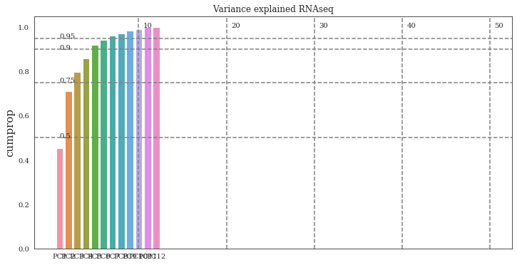

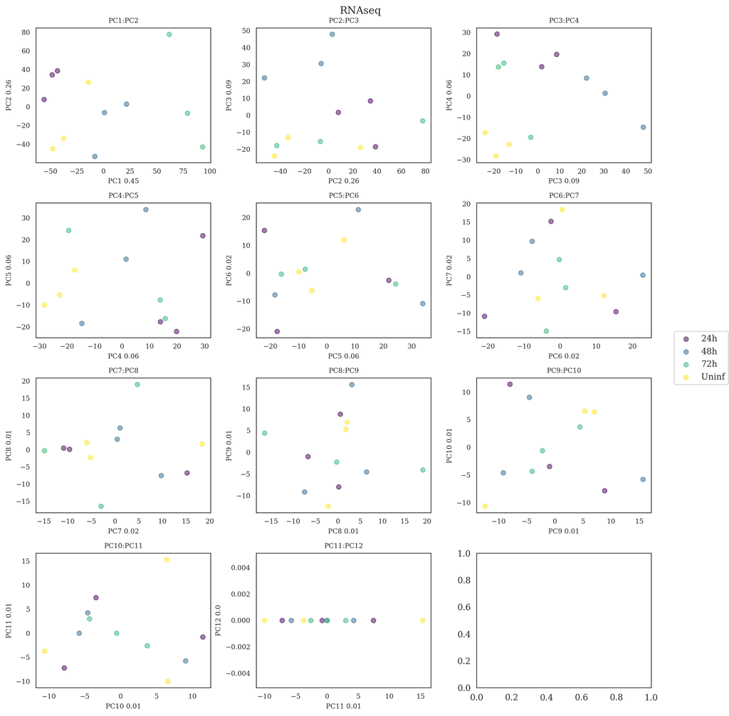

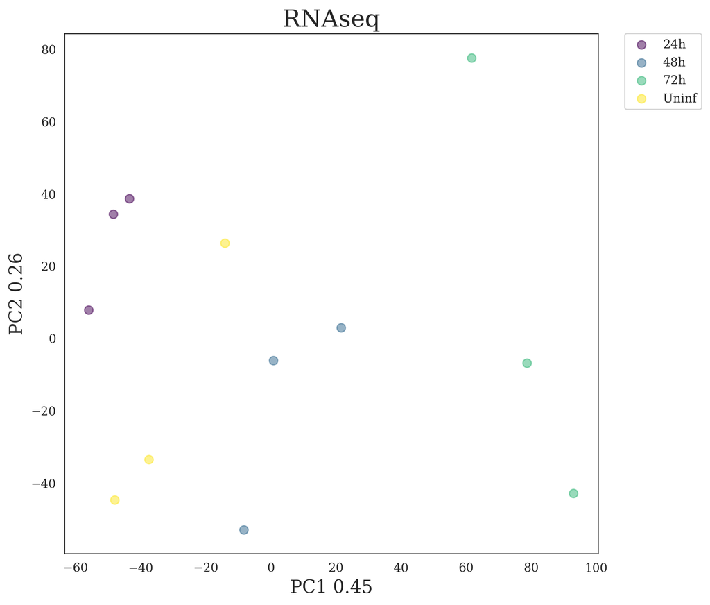

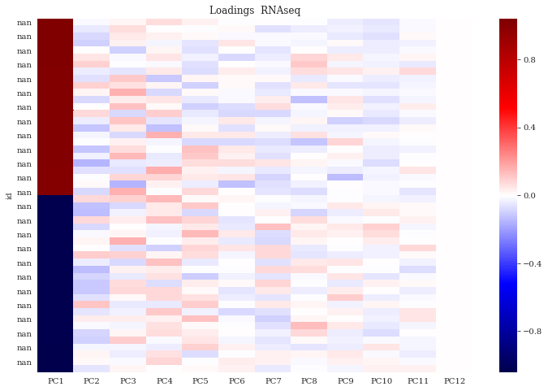

```python
rna.columns=rna.columns.str.replace('.+\_','')

rna_pca=aa.PCA_pipeline(rna.T, results)
rna_pca.PCA_full(normalization='standardize', na_replace=0, title='RNAseq')
```

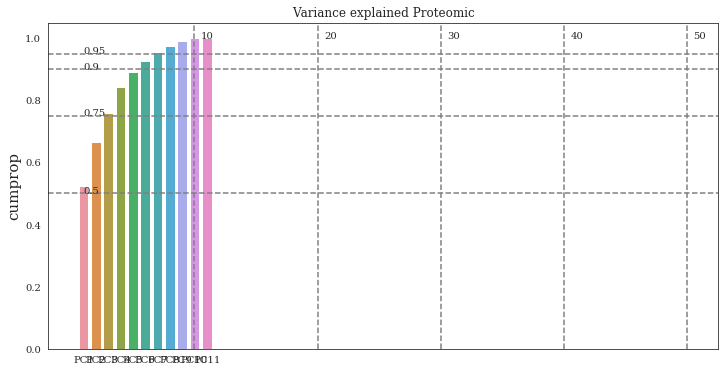

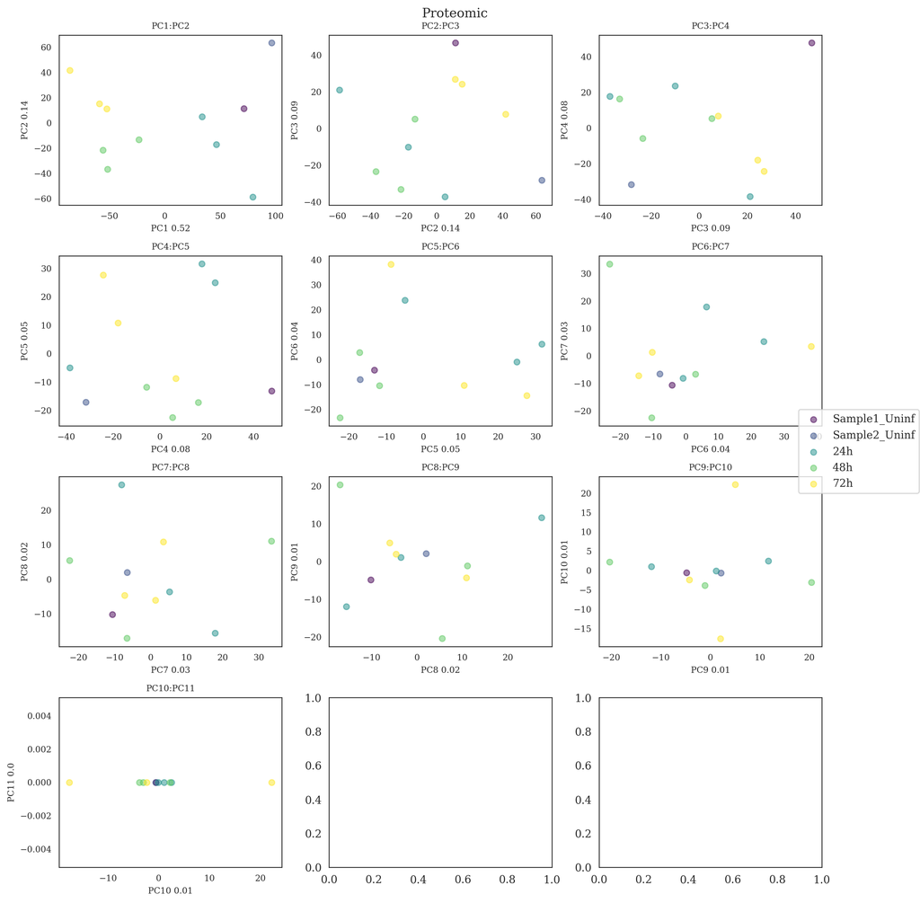

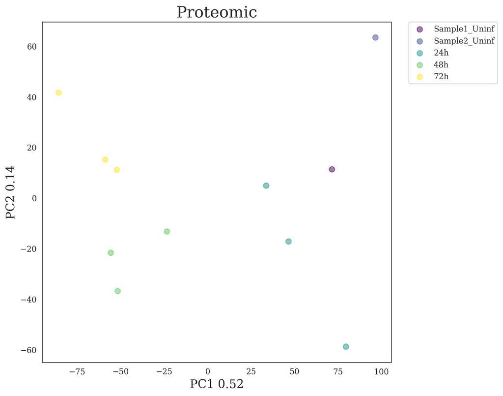

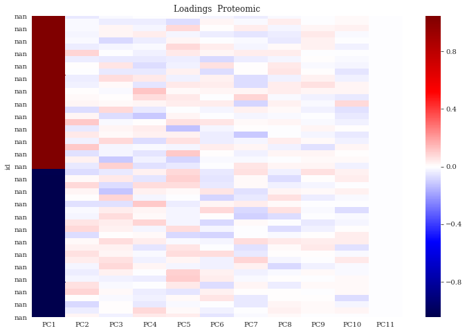

```python
prot.columns=prot.columns.str.replace('.+\_(..h)','\\1')

prot_pca=aa.PCA_pipeline(prot.T, results)
prot_pca.PCA_full(normalization='standardize', na_replace=0, title='Proteomic')
```

## Association analysis

```
Computing fast correlation....
Correcting P values for 15643621 tested correlations.
Found:

3084804 correlations at Q < 0.05. -1.0 < R < -0.71 | 0.71 < R < 1.0
1236689 correlations at Q < 0.01. -1.0 < R < -0.71 | 0.83 < R < 1.0
210216 correlations at Q < 0.001. -1.0 < R < -0.71 | 0.93 < R < 1.0
27934 correlations at Q < 0.0001. -1.0 < R < -0.71 | 0.97 < R < 1.0
```

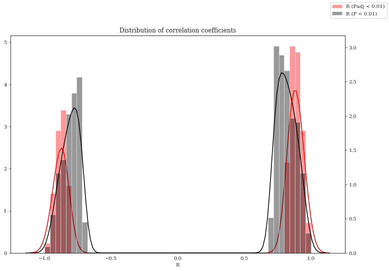

```python
reload(aa)

## RNAseq
my_association=aa.association_analysis(rna.T, results_path=results+'/rnaseq/')
my_association.correlate()
my_association.correlation_metrics(0.01)
```

```
Computing fast correlation....
Correcting P values for 29119896 tested correlations.
Found:

6996444 correlations at Q < 0.05. -1.0 < R < -0.72 | 0.72 < R < 1.0
2595659 correlations at Q < 0.01. -1.0 < R < -0.72 | 0.85 < R < 1.0
396617 correlations at Q < 0.001. -1.0 < R < -0.72 | 0.94 < R < 1.0
50030 correlations at Q < 0.0001. -1.0 < R < -0.72 | 0.98 < R < 1.0
```

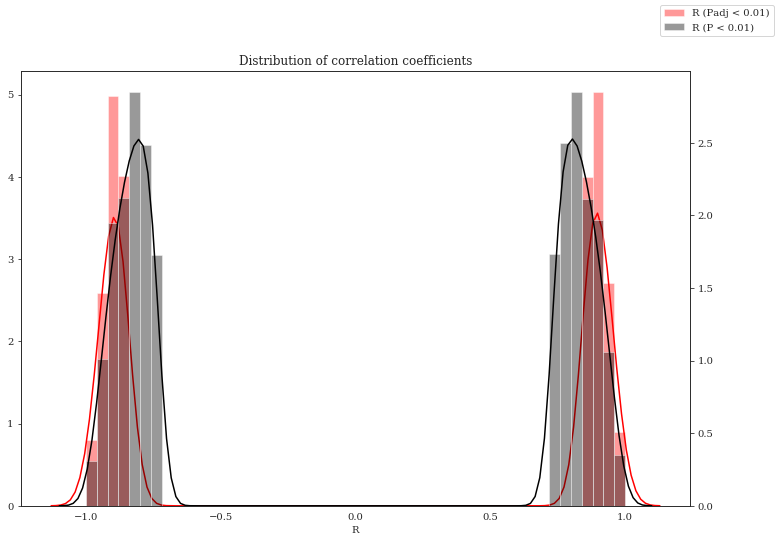

```python
## Proteomic
prot_aa=aa.association_analysis(prot.T, results_path=results+'/proteomics/')
prot_aa.correlate()
prot_aa.correlation_metrics(0.01)
```

## Network analysis

```python
rna_bkgd=rna.shape[0]
prot_bkgd=prot.shape[0]
```

```python
rna_aa=pd.read_csv(results+'/rnaseq/association_analysis/Correlation_matrix_long_deduplicated_Q01.txt', sep="\t")
prot_aa=pd.read_csv(results+'/proteomics/association_analysis/Correlation_matrix_long_deduplicated_Q01.txt', sep="\t")

dict_aa={
    'rnaseq':rna_aa[['val1','val2','R']],
    'proteomics':prot_aa[['val1','val2','R']]
}
```

```python
def build_process_network(name, pos_neg, bkgd):
    my_ass=dict_aa[name]

    if(pos_neg=='pos'):
        my_ass=my_ass.loc[my_ass.R>0]
    elif(pos_neg=='neg'):
        # negative weights are converted to positive so that weighted networks can be used
        my_ass=my_ass.loc[my_ass.R<0]
        my_ass.R=my_ass.R*-1
    else:
        print('Problem')


    mynet=na.network_analysis(my_ass, main_dir=results+name+'/'+pos_neg+'/', output_name=name+'_network')
    ns=mynet.build_network(weighted=True)
    nc=mynet.centralities_compute().head()
    cf,cfs=mynet.community_detection(weighted=True)
    en=mynet.enrichment(organism='human', background=bkgd)
    return(ns,nc,cf,cfs,en)
```

### Positive correlations

[output not shown]

```
(            node_count edge_count diameter av_path_length    density  \
 Network           5532     764803       12        4.06875  0.0499912
 Erdos_Renyi       5532     764803        3        1.95001  0.0499912

             clustering_coef connected? minimum_cut
 Network            0.621445      False           0
 Erdos_Renyi       0.0499694       True         220  ,
           graph  degree  eccentricity  betweeness  closeness       deg_w  \
 TSPAN6  network    46.0          10.0    0.000172   0.151671   39.671329
 USP33   network   165.0           9.0    0.000978   0.156353  145.146853
 UAP1    network   404.0          10.0    0.001076   0.157350  358.615385
 ZNF189  network   252.0          10.0    0.000527   0.153498  219.244755
 UQCRB   network    19.0           9.0    0.000314   0.151884   16.300699

            btw_w     cls_w  degree_rank  betweeness_rank  closeness_rank  \
 TSPAN6  0.000307  0.170941     0.221258         0.263196        0.127260
 USP33   0.001151  0.176258     0.465835         0.858279        0.259219
 UAP1    0.000769  0.177109     0.722975         0.880152        0.294649
 ZNF189  0.000653  0.173206     0.567968         0.649313        0.166486
 UQCRB   0.000199  0.171041     0.126085         0.441793        0.130694

         eccentricity_rank
 TSPAN6           0.113521
 USP33            0.494487
 UAP1             0.113521
 ZNF189           0.113521
 UQCRB            0.494487  ,
            Comm  Edges  Comm1  Comm2
 7   CC1_1:CC1_2   1713  CC1_1  CC1_2
 13  CC1_1:CC1_4      1  CC1_1  CC1_4
 5   CC1_1:CC1_5   8031  CC1_1  CC1_5
 11  CC1_2:CC1_3    140  CC1_2  CC1_3
 2   CC1_2:CC1_4  31303  CC1_2  CC1_4
 10  CC1_2:CC1_5     25  CC1_2  CC1_5
 4   CC1_3:CC1_4  91338  CC1_3  CC1_4
 8   CC1_3:CC1_5   3116  CC1_3  CC1_5
 12  CC1_4:CC1_5    133  CC1_4  CC1_5,
   CC_comm_id                                                val  size
 0      CC1_1  [TSPAN6, USP33, UAP1, ZNF189, UQCRB, VIRMA, UG...  1348
 1      CC1_2  [DPM1, RPAP3, VTA1, UTP18, NDUFS1, NUP160, FAM...  1325
```

[output cut: 28 more lines]

```

                                                 Genes
 0   RPL4;RPL5;TRAM1;RPL30;RPL3;RPL32;RPL31;RPL34;R...
 1   RPL4;RPL5;RPL30;RPL3;RPL32;RPL31;RPL34;RPLP0;R...
 2   RPL4;RPL5;RPL30;SMG1;RPL3;RPL32;RPL31;RPL34;RP...
 3   RPL4;RPL5;RPL30;RPL3;RPL32;RPL31;RPL34;RPLP0;R...
 4   RPL4;RPL5;RPL30;CCNT2;RPL3;RPL32;RPL31;RPL34;R...
 ..                                                ...
 2   HDAC5;CEBPB;PIGO;SLC44A2;ADM;FBLN1;TNFAIP1;EGF...
 3   SCARB1;EGR1;SREBF1;PER1;NSDHL;APOC1;SCAP;KLHDC...
 6   RETSAT;ABHD4;LRP1;NR1H3;LAMC1;TSKU;HOXC10;ACLY...
 5      SRRM2;RING1;RER1;PCGF2;WDR6;PBXIP1;SQSTM1;CTSB
 4   CITED2;ZFAND2B;PBXIP1;RRBP1;LTBP3;SPG7;ATP1A1;...

 [915 rows x 5 columns])
```

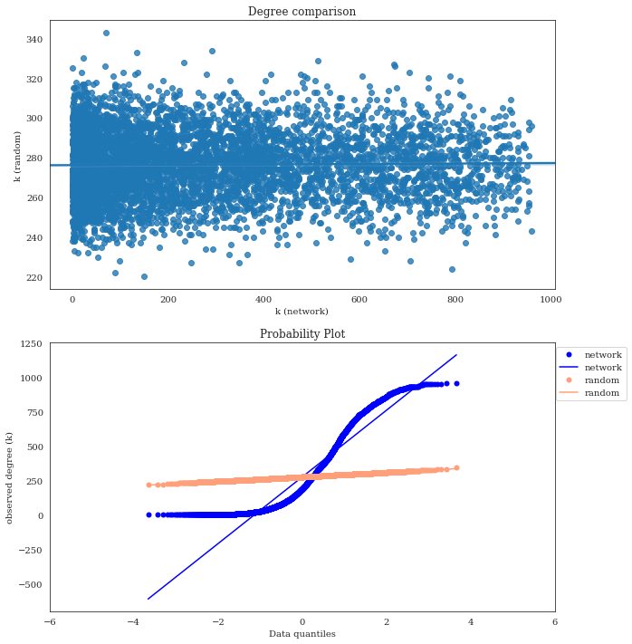

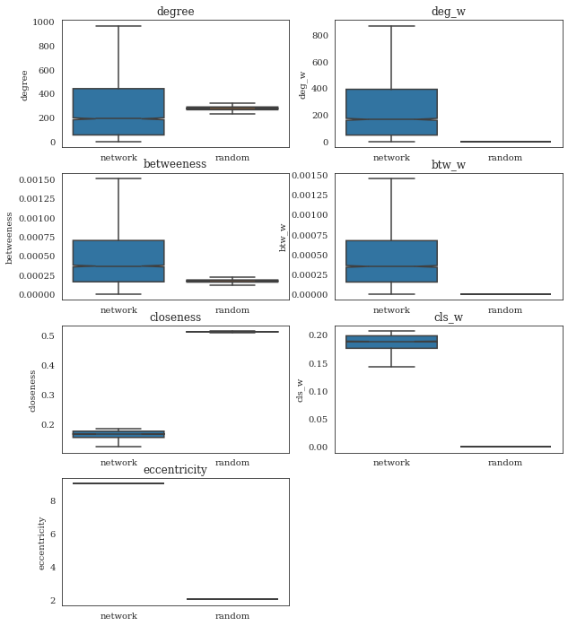

```python
display(build_process_network('rnaseq','pos',rna_bkgd))
```

[output not shown]

```
(            node_count edge_count diameter av_path_length   density  \
 Network           7517    1311851       16        4.84046  0.046439
 Erdos_Renyi       7517    1311851        3        1.95356  0.046439

             clustering_coef connected? minimum_cut
 Network             0.63449      False           0
 Erdos_Renyi       0.0464413       True         288  ,
         graph  degree  eccentricity  betweeness  closeness       deg_w  \
 A1BG  network   907.0          11.0    0.000092   0.024102  827.597385
 A1CF  network   898.0          11.0    0.000336   0.024129  814.659768
 A2M   network   849.0          11.0    0.000131   0.024092  771.820848
 AASS  network   646.0          11.0    0.000071   0.024041  578.759625
 ABAT  network   786.0          11.0    0.000169   0.024084  710.150602

          btw_w     cls_w  degree_rank  betweeness_rank  closeness_rank  \
 A1BG  0.000044  0.024470     0.877411         0.188173        0.847013
 A1CF  0.000064  0.024497     0.870294         0.661035        0.910802
 A2M   0.000121  0.024467     0.843156         0.270520        0.817613
 AASS  0.000088  0.024419     0.735466         0.155115        0.639085
 ABAT  0.000151  0.024457     0.811893         0.371159        0.795730

       eccentricity_rank
 A1BG           0.527072
 A1CF           0.527072
 A2M            0.527072
 AASS           0.527072
 ABAT           0.527072  ,
           Comm   Edges  Comm1  Comm2
 6  CC1_1:CC1_2    4638  CC1_1  CC1_2
 5  CC1_2:CC1_3    1492  CC1_2  CC1_3
 7  CC1_2:CC1_4    2654  CC1_2  CC1_4
 1  CC1_3:CC1_4  158324  CC1_3  CC1_4,
   CC_comm_id                                                val  size
 0      CC1_1  [AADAC, CNTROB, AAGAB, ABCC5, ABLIM1, ACTR6, A...  2529
 1      CC1_2  [AAK1, MCL1, MEN1, MRTO4, UPF1, UQCRC1, VPS4B,...  2221
 2      CC1_3  [ABHD3, ACAP3, ACSF3, ADAD1, AFP, AIFM2, ALG12...  1375
 3      CC1_4  [A1BG, A1CF, A2M, AASS, ABAT, ABCB7, ABCC4, AB...  1344,
      comm                    Gene_set  \
 0   CC1_1  GO_Biological_Process_2018
 1   CC1_1  GO_Biological_Process_2018
```

[output cut: 22 more lines]

```

                                                 Genes
 0   RPL5;ISCA2;RPL30;RPL32;RPL31;RPL34;CASC3;RPL8;...
 1   PDCD7;CWC25;CASC3;CCAR1;PNN;RBMX2;MAGOH;CWC22;...
 2   PDCD7;CWC25;CASC3;CCAR1;PNN;RBMX2;MAGOH;CWC22;...
 3   CCNH;PDCD7;CWC25;CASC3;CCAR1;PNN;RBMX2;MAGOH;C...
 4   LTV1;RPL5;RPL30;RPL32;RPL31;RPL34;RRP1;RPL8;RP...
 ..                                                ...
 2   CPM;ACSS2;RETSAT;ADH1B;GBE1;ETFDH;HSD17B12;NID...
 3   TRAM1;DDC;SEC23A;RETSAT;PANK1;MAOA;MTTP;ETFDH;...
 4   DMGDH;MIPEP;DDC;ACY1;USH1C;PEPD;SLC4A4;BPHL;AC...
 5   PI4K2B;MTCH2;PDCD6;PREP;HNRNPR;ENO1;APEH;SMC3;...
 6   NRP1;FKBP10;COPB2;CUL7;SEC23A;FAM114A1;GBE1;LA...

 [1393 rows x 5 columns])
```

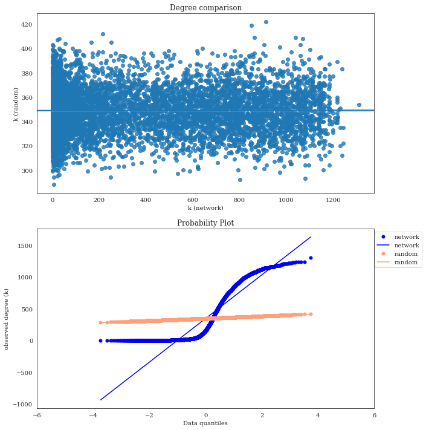

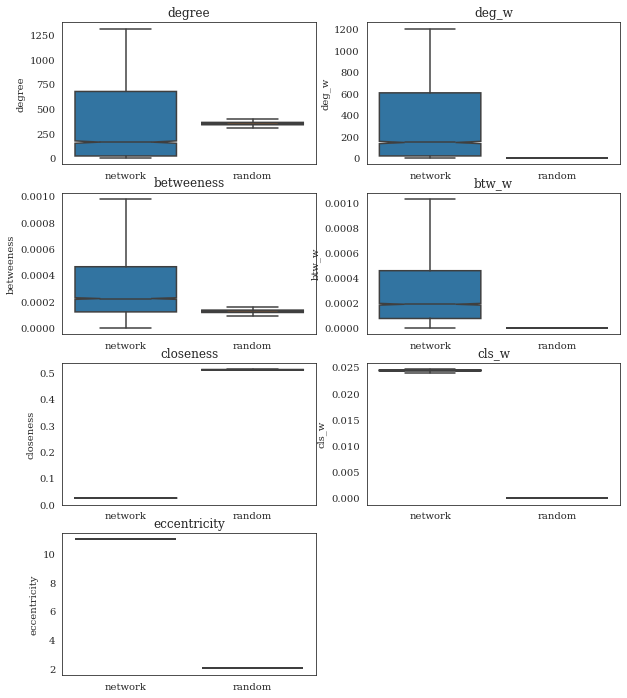

```python
display(build_process_network('proteomics','pos',prot_bkgd))
```

### Negative correlations

[output not shown]

```
(            node_count edge_count diameter av_path_length    density  \
 Network           5394     471886       11        3.40213  0.0324434
 Erdos_Renyi       5394     471886        3        1.97085  0.0324434

             clustering_coef connected? minimum_cut
 Network                   0      False           0
 Erdos_Renyi       0.0324079       True         135  ,
           graph  degree  eccentricity  betweeness  closeness       deg_w  \
 TSPAN6  network   147.0           7.0    0.000141   0.189168  125.370629
 USP36   network    38.0           7.0    0.000153   0.188870   32.790210
 ZNF629  network   215.0           8.0    0.000367   0.198221  189.307692
 UBE2S   network   338.0           7.0    0.000329   0.204242  300.545455
 ZNF142  network   270.0           7.0    0.000278   0.200924  237.671329

            btw_w     cls_w  degree_rank  betweeness_rank  closeness_rank  \
 TSPAN6  0.000303  0.210800     0.567946         0.322581        0.486003
 USP36   0.000228  0.210325     0.263812         0.338895        0.477660
 ZNF629  0.000382  0.219911     0.684279         0.593808        0.749351
 UBE2S   0.000267  0.226074     0.839173         0.552280        0.911476
 ZNF142  0.000234  0.222712     0.761216         0.498146        0.818131

         eccentricity_rank
 TSPAN6           0.693919
 USP36            0.693919
 ZNF629           0.214590
 UBE2S            0.693919
 ZNF142           0.693919  ,
           Comm  Edges  Comm1  Comm2
 4  CC1_1:CC1_2   3888  CC1_1  CC1_2
 3  CC1_1:CC1_3  34283  CC1_1  CC1_3
 9  CC1_1:CC1_4    299  CC1_1  CC1_4
 1  CC1_2:CC1_3  68071  CC1_2  CC1_3
 6  CC1_2:CC1_4    570  CC1_2  CC1_4
 7  CC1_3:CC1_4    677  CC1_3  CC1_4,
   CC_comm_id                                                val  size
 0      CC1_1  [DPM1, PLEKHG6, NPC1L1, NR1H3, SIRT2, MNT, ZXD...  2144
 1      CC1_2  [TSPAN6, USP36, ZNF629, ZNF142, TUBGCP2, CFH, ...  1801
 2      CC1_3  [UBE2S, UCK1, YDJC, LAS1L, ELAC2, DNAJC11, PPP...  1152
 3      CC1_4  [SELENOH, KIF22, COA4, TIMELESS, MRPL2, MSTO1,...   274,
      comm                    Gene_set  \
```

[output cut: 24 more lines]

```

                                                 Genes
 0   DBR1;DDX46;EIF4A3;DDX42;HNRNPU;PPWD1;HNRNPR;CA...
 1   DBR1;DDX46;EIF4A3;DDX42;HNRNPU;PPWD1;HNRNPR;CA...
 2   DBR1;DDX46;EIF4A3;DDX42;HNRNPU;PPWD1;HNRNPR;CA...
 3   RPL3;NUP107;EIF4A3;HNRNPU;CASC3;PWP1;GLE1;ALKB...
 4   YWHAE;NUP205;NUP107;HSP90AB1;SEH1L;AAAS;NUP160...
 ..                                                ...
 25  PIF1;RPL12;THAP1;RPS28;FUBP3;RPL27A;RPL36;TIME...
 26                        SELENOS;RACK1;TMBIM6;HSPA1A
 27                         RAB32;BLOC1S4;SNAPIN;RAB29
 0   RPS28;MRPL2;RPL27A;RPL12;RPL36;RPL38;RPS20;RPL...
 0   TNFRSF10B;LAMC1;CXCL5;ICAM1;RAB32;DPP4;BMP2;EF...

 [833 rows x 5 columns])
```

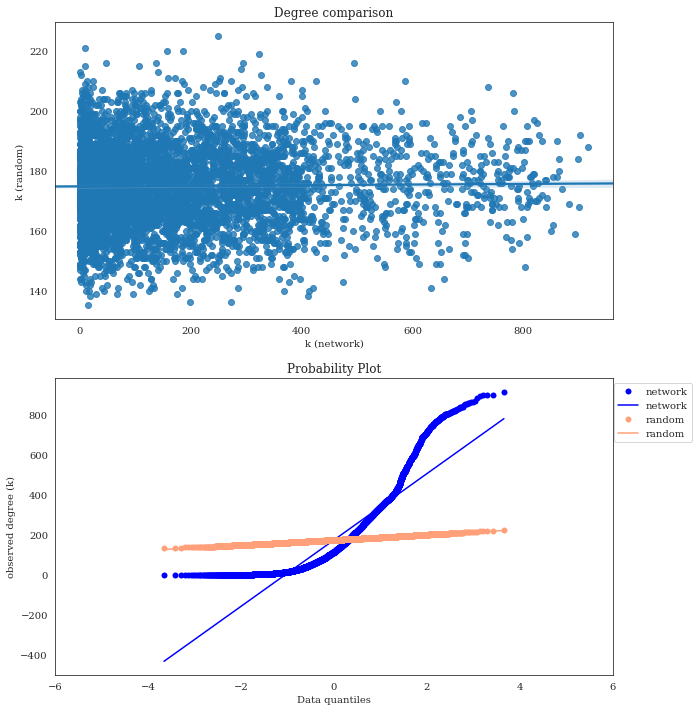

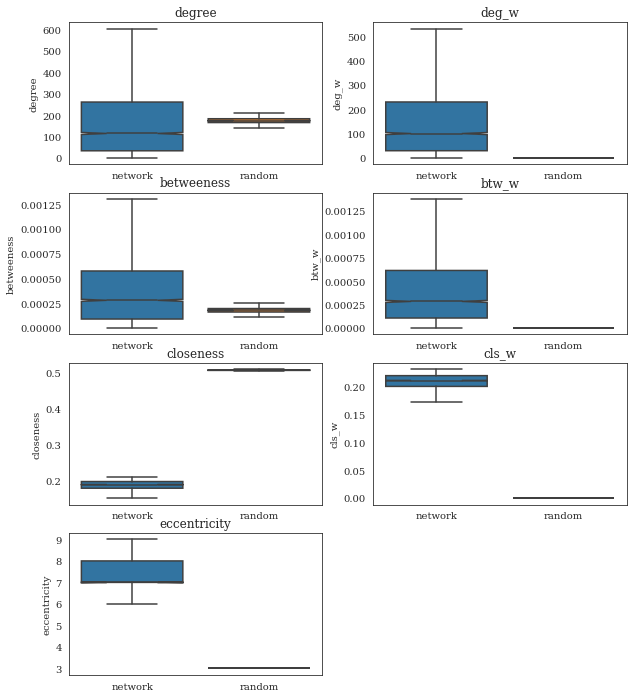

```python
display(build_process_network('rnaseq','neg',rna_bkgd))
```

[output not shown]

```
(            node_count edge_count diameter av_path_length    density  \
 Network           7452    1283808       14         3.6285  0.0462426
 Erdos_Renyi       7452    1283808        3        1.95376  0.0462426

             clustering_coef connected? minimum_cut
 Network                   0      False           0
 Erdos_Renyi       0.0462287       True         276  ,
           graph  degree  eccentricity  betweeness  closeness        deg_w  \
 A1BG    network   834.0           8.0    0.000292   0.045684   755.922975
 AAGAB   network   465.0           9.0    0.000493   0.045246   413.717913
 ABHD13  network  1049.0           9.0    0.000478   0.045748   957.842033
 ABLIM1  network  1152.0           9.0    0.000518   0.045849  1043.372593
 ACIN1   network  1144.0           9.0    0.000445   0.045865  1043.956861

            btw_w     cls_w  degree_rank  betweeness_rank  closeness_rank  \
 A1BG    0.000236  0.046555     0.841855         0.464775        0.866680
 AAGAB   0.000772  0.046174     0.652509         0.787976        0.632716
 ABHD13  0.000184  0.046605     0.955918         0.772343        0.903113
 ABLIM1  0.000254  0.046696     0.989868         0.811997        0.978395
 ACIN1   0.000078  0.046708     0.987587         0.728328        0.987453

         eccentricity_rank
 A1BG             0.957528
 AAGAB            0.627348
 ABHD13           0.627348
 ABLIM1           0.627348
 ACIN1            0.627348  ,
           Comm   Edges  Comm1  Comm2
 2  CC1_1:CC1_2   23189  CC1_1  CC1_2
 4  CC1_1:CC1_3   42367  CC1_1  CC1_3
 1  CC1_2:CC1_3  285400  CC1_2  CC1_3,
   CC_comm_id                                                val  size
 0      CC1_1  [APC, C11orf98, C1orf159, CSTF2, EXOSC6, MEX3D...  3139
 1      CC1_2  [A1BG, AAGAB, ABHD13, ABLIM1, ADAM15, ADGRA3, ...  2386
 2      CC1_3  [ACIN1, AFF4, AJUBA, AKAP17A, AKAP2, AKAP5, AP...  1906,
      comm                    Gene_set  \
 0   CC1_1  GO_Biological_Process_2018
 1   CC1_1  GO_Biological_Process_2018
 2   CC1_1  GO_Biological_Process_2018
 4   CC1_1  GO_Biological_Process_2018
```

[output cut: 20 more lines]

```

                                                 Genes
 0   RPL4;RPL3;RPL10L;HNRNPU;NR3C1;RPL9;PWP1;YARS2;...
 1   TXNL4B;PDCD7;GEMIN2;HNRNPU;GPATCH1;CWC27;SNRPD...
 2   RPL4;RPL3;MRE11;RPL10L;NR3C1;PWP1;RPL9;YARS2;R...
 4   PDCD7;DDX42;HNRNPU;GPATCH1;PRPF19;CWC27;USP39;...
 3   PDCD7;GEMIN2;HNRNPU;GPATCH1;CWC27;ALKBH5;SNRPD...
 ..                                                ...
 3   FEN1;TFRC;LDB1;CSE1L;WDR3;BCCIP;C1ORF174;MTR;M...
 2   ATF2;NUP107;TP53RK;CSE1L;ZMYND8;PEX26;EIF4ENIF...
 4   SCARB2;CYFIP1;SMARCAL1;WDR48;ADPGK;SLC35B1;GDI...
 5   FAM49B;WIPF2;DYSF;JMJD1C;RBPJ;IFIT1;BACH1;NIPB...
 6   PHF3;ATF2;TRMU;DIDO1;EIF4A1;RBM26;NUMA1;TMEM41...

 [1243 rows x 5 columns])
```

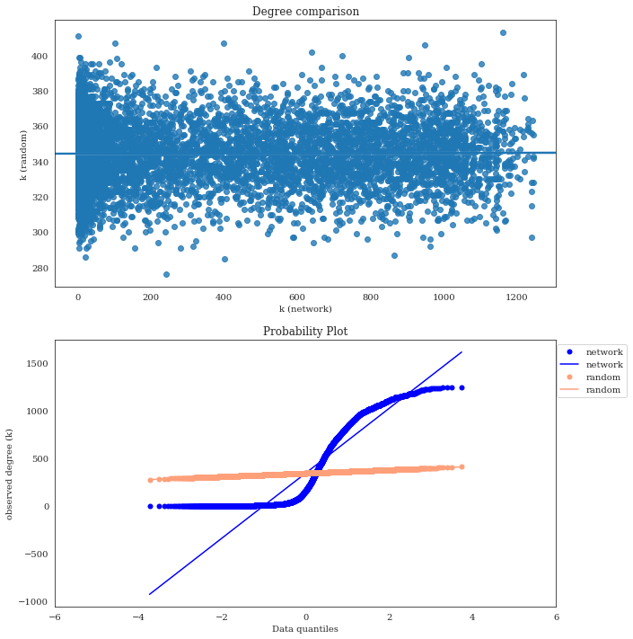

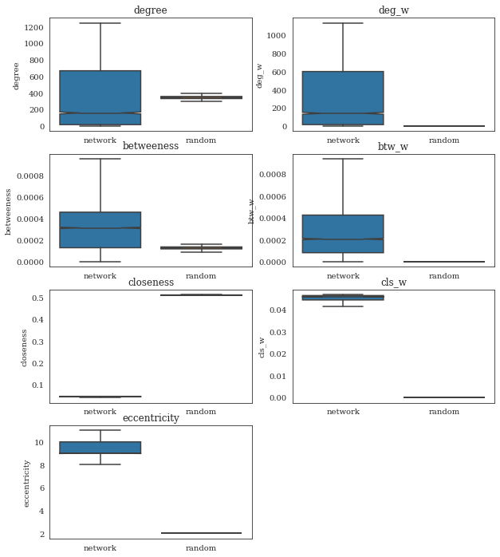

```python
display(build_process_network('proteomics','neg',prot_bkgd))
```

# Functional analysis

```python
rna_pos=minor_functions.loadsave.loadme(results+'rnaseq/pos/rnaseq_network.pickle')
rna_neg=minor_functions.loadsave.loadme(results+'rnaseq/neg/rnaseq_network.pickle')

prot_pos=minor_functions.loadsave.loadme(results+'proteomics/pos/proteomics_network.pickle')
prot_neg=minor_functions.loadsave.loadme(results+'proteomics/neg/proteomics_network.pickle')
```

### Overlap between functions

```python
rna_pos.enrichment_output
```

[output not shown]

```python
# from statsmodels.stats.multitest import multipletests

def get_functional_overlap(net_obj1,net_obj2,gene_set=None,FDRthr=0.05, FDR_method='fdr_bh',verbose=False):
    """
    Compares communities of two networks to find the most similar communities through hypergeometric testing.

    Total GSEA terms used as input from those passing significance in the 2 networks.

    """
    if(gene_set!=None):
        er1=net_obj1.enrichment_output.loc[net_obj1.enrichment_output.Gene_set==gene_set].copy()
        er2=net_obj2.enrichment_output.loc[net_obj2.enrichment_output.Gene_set==gene_set].copy()
    else:
        er1=net_obj1.enrichment_output.copy()
        er2=net_obj2.enrichment_output.copy()

    er1=er1.loc[er1['Adjusted P-value']<FDRthr]
    er2=er2.loc[er2['Adjusted P-value']<FDRthr]

    #total terms in the entire network that pass significance
    total_terms=pd.unique(np.append(er1['Term'].values,er2['Term'].values))

    #comms
    cc1_list=er1['comm'].unique()
    cc2_list=er2['comm'].unique()

    if(verbose):
        print('FDR chosen: ',str(FDRthr))
        print('# communities in network 1: ',str(len(cc1_list)))
        print('# communities in network 2: ',str(len(cc2_list)))
        print('# universe biological processes: ',str(len(total_terms)))

    overlap_terms=pd.DataFrame()

    for cc1 in cc1_list:
        for cc2 in cc2_list:
            df1=er1.loc[er1.comm==cc1,]
            df2=er2.loc[er2.comm==cc2,]

            #Gene Set intersection
            t1=df1.loc[:,'Term'].values
            t2=df2.loc[:,'Term'].values
            inter=np.intersect1d(t1,t2)
            hypergeom_c1c2=aa.hypergeom_list(total_terms, t1, t2)

            intersecting_genes=[]
            for iterm in inter:
                g1=df1.loc[df1.Term==iterm,'Genes'].values[0].split(';')
                g2=df2.loc[df2.Term==iterm,'Genes'].values[0].split(';')
                intersecting_genes=np.append(intersecting_genes,
                    ';'.join(np.intersect1d(g1,g2))
                                            )


            if(verbose):
                print(f'Comm1: {cc1} (n: {len(t1)}) | Comm2: {cc2} (n: {len(t2)}) | Intersection: {len(inter)} | P: {hypergeom_c1c2}')

            out=pd.Series(
                [cc1,cc2,hypergeom_c1c2,
                 len(inter),inter,t1,len(t1),t2,len(t2),intersecting_genes,len(intersecting_genes)],
                index=['Net1_comm','Net2_comm','P',
                       'n_inter','inter','Comm1_vals','n_Comm1_vals','Comm2_vals','n_Comm2_vals','intgenes_for_interterms','n_intgenes']
            )
            overlap_terms=pd.concat([overlap_terms, out],1)

    overlap_terms=overlap_terms.T.reset_index(drop=True)
    overlap_terms['FDR']=multipletests(overlap_terms['P'], method=FDR_method)[1]
    overlap_terms=overlap_terms.loc[overlap_terms.FDR<FDRthr]
    return(overlap_terms)

get_functional_overlap(rna_pos,prot_pos,gene_set='KEGG_2019_Human')
```

|  | Net1_comm | Net2_comm | P | n_inter | inter | Comm1_vals | n_Comm1_vals | Comm2_vals | n_Comm2_vals | intgenes_for_interterms | n_intgenes | FDR |
| --- | --- | --- | --- | --- | --- | --- | --- | --- | --- | --- | --- | --- |
| 4 | CC1_2 | CC1_1 | 0.00764677 | 6 | [Protein processing in endoplasmic reticulum, RNA transport, Ribosome, Ribosome biogenesis in eukaryotes, Spliceosom... | [Spliceosome, Cell cycle, RNA transport, Oxidative phosphorylation, Parkinson disease, Ribosome biogenesis in eukary... | 34 | [Ribosome, Spliceosome, RNA transport, Endocytosis, Adherens junction, Protein processing in endoplasmic reticulum, ... | 11 | [BAG2;CANX;DNAJA1;DNAJA2;DNAJB11;HSPA5;HSPA8;HSPH1;UBQLN1;YOD1, DDX20;EIF1AX;EIF3J;EIF5B;MAGOH;NUP153;NUP50;NUP58;PN... | 6 | 0.0254892 |
| 5 | CC1_2 | CC1_2 | 1.65116e-06 | 16 | [Alzheimer disease, Cell cycle, DNA replication, Huntington disease, Non-alcoholic fatty liver disease (NAFLD), Nucl... | [Spliceosome, Cell cycle, RNA transport, Oxidative phosphorylation, Parkinson disease, Ribosome biogenesis in eukary... | 34 | [Autophagy, Thermogenesis, Parkinson disease, Alzheimer disease, Oxidative phosphorylation, Non-alcoholic fatty live... | 29 | [ATP5F1C;ATP5PB;ATP5PD;CALM1;COX7B;NDUFA4;NDUFA5;NDUFB3;NDUFC2;UQCRFS1;UQCRH, BUB3;CDC23;CDC7;HDAC2;MCM3;MCM4;MCM6;P... | 16 | 1.10077e-05 |
| 7 | CC1_2 | CC1_4 | 1.1002e-06 | 23 | [Cell cycle, Cellular senescence, DNA replication, Epstein-Barr virus infection, Human T-cell leukemia virus 1 infec... | [Spliceosome, Cell cycle, RNA transport, Oxidative phosphorylation, Parkinson disease, Ribosome biogenesis in eukary... | 34 | [Lysosome, RNA transport, Ubiquitin mediated proteolysis, Endocytosis, Proteasome, Protein processing in endoplasmic... | 55 | [ANAPC4;ANAPC5;CDC27;CDK2;CUL1;HDAC1;MAD2L1;PRKDC;RBX1;YWHAE;YWHAQ, CDK2;HUS1;PPP1CB;VDAC2;VDAC3, RFC5;RPA1, CALR;CD... | 23 | 1.1002e-05 |
| 9 | CC1_3 | CC1_2 | 0.00644669 | 7 | [Endocytosis, Huntington disease, Parkinson disease, Protein processing in endoplasmic reticulum, Ribosome, Thermoge... | [Protein processing in endoplasmic reticulum, Ribosome, Hepatocellular carcinoma, Base excision repair, Lysosome, Th... | 16 | [Autophagy, Thermogenesis, Parkinson disease, Alzheimer disease, Oxidative phosphorylation, Non-alcoholic fatty live... | 29 | [ARFGAP1;CLTB;EPN1;GRK2;GRK6;HSPA2;RAB11B;SH3GLB2, ATP5F1D;BAX;CLTB;COX5B;CYC1;DCTN1;NDUFA2;NDUFS7;SLC25A6;UQCR10;UQ... | 7 | 0.0254892 |
| 12 | CC1_4 | CC1_1 | 0.000235214 | 6 | [Pathogenic Escherichia coli infection, RNA transport, Ribosome, Ribosome biogenesis in eukaryotes, Spliceosome, mRN... | [Proteasome, Spliceosome, RNA transport, Ribosome biogenesis in eukaryotes, Huntington disease, Thermogenesis, Parki... | 19 | [Ribosome, Spliceosome, RNA transport, Endocytosis, Adherens junction, Protein processing in endoplasmic reticulum, ... | 11 | [ACTG1;ARPC4;EZR;KRT18, ACIN1;ALYREF;EIF2B2;EIF4G1;ELAC2;FXR2;POP7;RAE1;RNPS1;SUMO3;TACC3, MRPL14;MRPL15;MRPL2;MRPS1... | 6 | 0.00117607 |
| 13 | CC1_4 | CC1_2 | 6.4931e-08 | 13 | [Alzheimer disease, Apoptosis, Cell cycle, Huntington disease, Non-alcoholic fatty liver disease (NAFLD), Oxidative ... | [Proteasome, Spliceosome, RNA transport, Ribosome biogenesis in eukaryotes, Huntington disease, Thermogenesis, Parki... | 19 | [Autophagy, Thermogenesis, Parkinson disease, Alzheimer disease, Oxidative phosphorylation, Non-alcoholic fatty live... | 29 | [BID;COX4I1;COX5A;COX6B1;NDUFA8;NDUFB11;NDUFS3;NDUFV3, BID;BIRC5, ANAPC7;CDK4;MCM7;ORC1, COX4I1;COX5A;COX6B1;DCTN2;N... | 13 | 1.29862e-06 |

### Most central communities in each network

```python
rna
```

|  | CC_comm_id | val | size | mean_degree | mean_eccentricity | mean_betweeness | mean_closeness | mean_deg_w | mean_btw_w | mean_cls_w | mean_degree_rank | mean_betweeness_rank | mean_closeness_rank | mean_eccentricity_rank | degree_norm |
| --- | --- | --- | --- | --- | --- | --- | --- | --- | --- | --- | --- | --- | --- | --- | --- |
| 0 | CC1_1 | TSPAN6;USP33;UAP1;ZNF189;UQCRB;VIRMA;UGP2;CFH;TMEM176A;CFLAR;TFPI;RBM5;SLC7A2;PON1;PGM3;RWDD2A;CLK1;UFL1;SERPINB1;IF... | 1355 | 164.84944649446496 | 9.567527675276752 | 0.000492883851717142 | 0.15263622408172994 | 145.9538358320646 | 0.0004942569370293301 | 0.17203494894736648 | 0.39865052175467525 | 0.48060929633157506 | 0.19205221282147747 | 0.28628843121403014 | 0.121660 |
| 1 | CC1_2 | DPM1;RPAP3;VTA1;UTP18;NDUFS1;NUP160;FAM136A;SPDL1;PSMA4;POLR2B;MRPS10;MAPK9;NOP58;GDI2;NDC1;MRPS35;WAPL;INTS13;TNPO3... | 1311 | 194.3119755911518 | 8.831426392067124 | 0.0006444908623485905 | 0.16914074730034317 | 171.60491910835162 | 0.0006419961738446964 | 0.18949842172092385 | 0.4285586447176762 | 0.5391717173722762 | 0.5629407130167838 | 0.5620812106029797 | 0.148217 |
| 2 | CC1_3 | VPS26B;SYNM;PLEKHO1;MAP2K3;SZRD1;SLC4A11;MCOLN1;MYH9;RANGAP1;POLR3H;PYGB;PIEZO1;STX4;PYCR3;TRMT1;SGTA;UBE2S;SMARCD2;... | 1206 | 470.3051409618574 | 9.066334991708127 | 0.00044020172214075196 | 0.1748541971434684 | 419.1480824316644 | 0.0004418777091169769 | 0.195556002067684 | 0.6964136146215175 | 0.44743248687869397 | 0.695046474664518 | 0.47096007969312276 | 0.389971 |
| 3 | CC1_4 | NFYA;LAP3;HCCS;PROM1;UBE3C;RTF2;STRAP;TOMM34;VCL;RPL26L1;NSUN2;LSG1;NOP16;MRTO4;TRAPPC3;IL17RB;RNF4;KARS1;YBX1;POLR1... | 901 | 469.0410654827969 | 8.32408435072142 | 0.0004912169169436865 | 0.17804958817140576 | 416.9376062339436 | 0.0004799625058267942 | 0.19883197120536408 | 0.6929603605859321 | 0.5185347805884519 | 0.8004232061588192 | 0.7600071584316616 | 0.520578 |
| 4 | CC1_5 | GNAS;TNFAIP1;PIAS3;MMS19;GUSB;VEGFB;PSAP;PRICKLE3;FAM3A;GRAMD1A;PLEKHG2;TOM1;NUCB1;SLC12A7;RTKN;HDHD3;FOXA2;RRBP1;NE... | 728 | 84.63049450549451 | 8.951923076923077 | 0.0007861488539594223 | 0.15614408951115144 | 74.55641473910705 | 0.0007990109732221404 | 0.175682784104901 | 0.2740589467473958 | 0.5371926970354302 | 0.285419671163977 | 0.5236391861934162 | 0.116251 |

```python
#computes mean community centrality

def community_centrality(network_in, centrality_metric='degree'):
    all_metrics=[ 'degree', 'eccentricity', 'betweeness', 'closeness', 'deg_w',
       'btw_w', 'cls_w', 'degree_rank', 'betweeness_rank', 'closeness_rank',
       'eccentricity_rank']
    communities=network_in.community_feats.copy()
    icentrality=network_in.centralities_network

    my_comm_centralities=pd.DataFrame()
    for cc in communities.CC_comm_id:
        temp=communities.loc[communities.CC_comm_id==cc,'val'].values[0]

        metric_cen=[]
        for cen_i in all_metrics:

            temp_cen=icentrality.loc[temp,cen_i]
            node_centrality=np.mean(temp_cen)
            metric_cen=np.append(metric_cen,node_centrality)

        out=pd.Series(np.append([cc],metric_cen), index=np.append(['CC_comm_id'],['mean_'+x for x in all_metrics]))
        my_comm_centralities=pd.concat([my_comm_centralities, out],1)

    my_comm_centralities=my_comm_centralities.T
    my_comm_centralities.reset_index(inplace=True,drop=True)

    out=pd.merge(communities, my_comm_centralities, on='CC_comm_id')

    full_net_size=out['size'].sum()
    out['degree_norm']=out.apply(lambda x: np.float(x['mean_degree'])/full_net_size,1)
    return(out)

# community_centrality(rna_pos)
```

```python
rna_pos.community_feats=community_centrality(rna_pos)
rna_neg.community_feats=community_centrality(rna_neg)

prot_pos.community_feats=community_centrality(prot_pos)
prot_neg.community_feats=community_centrality(prot_neg)
```

```python
minor_functions.loadsave.saveme(rna_pos,results+'rnaseq/pos/rnaseq_network_processed.pickle')
minor_functions.loadsave.saveme(prot_pos,results+'proteomics/pos/proteomics_network_processed.pickle')
```

```
File saved in /Users/rui.benfeitas/GitHub/sms4715_ujjwal/covid/results/rnaseq/pos/rnaseq_network_processed.pickle
File saved in /Users/rui.benfeitas/GitHub/sms4715_ujjwal/covid/results/proteomics/pos/proteomics_network_processed.pickle
```

# Results

```python
rna_pos=minor_functions.loadsave.loadme(results+'rnaseq/pos/rnaseq_network_processed.pickle')
prot_pos=minor_functions.loadsave.loadme(results+'proteomics/pos/proteomics_network_processed.pickle')
```

## Network features

```python
rna_pos.network_stats
```

|  | node_count | edge_count | diameter | av_path_length | density | clustering_coef | connected? | minimum_cut |
| --- | --- | --- | --- | --- | --- | --- | --- | --- |
| Network | 5532 | 764803 | 12 | 4.06875 | 0.0499912 | 0.621445 | False | 0 |
| Erdos_Renyi | 5532 | 764803 | 3 | 1.95001 | 0.0499912 | 0.0500151 | True | 214 |

```python
prot_pos.network_stats
```

|  | node_count | edge_count | diameter | av_path_length | density | clustering_coef | connected? | minimum_cut |
| --- | --- | --- | --- | --- | --- | --- | --- | --- |
| Network | 7517 | 1311851 | 16 | 4.84046 | 0.046439 | 0.63449 | False | 0 |
| Erdos_Renyi | 7517 | 1311851 | 3 | 1.95356 | 0.046439 | 0.0464465 | True | 284 |

## Most central genes/proteins

```python
#top 5% most central genes/proteins
np.intersect1d(
    rna_pos.centralities_network.sort_values(['degree_rank','betweeness_rank','closeness_rank','eccentricity_rank'], ascending=False).head(
    int(rna_pos.centralities_network.shape[0]*0.05)
    ).index,
prot_pos.centralities_network.sort_values(['degree_rank','betweeness_rank','closeness_rank','eccentricity_rank'], ascending=False).head(int(prot_pos.centralities_network.shape[0]*0.05)).index
)
```

```
array(['AP1B1', 'AP2A1', 'AP2S1', 'AP3D1', 'CAPN1', 'G6PD', 'GNB2',
       'SSR4', 'TMEM11', 'TRMT1', 'WDR5'], dtype=object)
```

```python
#top 1% most central genes/proteins
np.intersect1d(
    rna_pos.centralities_network.sort_values(['degree_rank','betweeness_rank','closeness_rank','eccentricity_rank'], ascending=False).head(
    int(rna_pos.centralities_network.shape[0]*0.01)
    ).index,
prot_pos.centralities_network.sort_values(['degree_rank','betweeness_rank','closeness_rank','eccentricity_rank'], ascending=False).head(int(prot_pos.centralities_network.shape[0]*0.01)).index
)
```

```
array(['G6PD'], dtype=object)
```

## Community and centrality

Community characteristics and centrality. Different centrality metrics were computed but we will frame our discussion on the normalized degree (i.e. number of connections between each gene/protein in a community, normalized by network size).

```python
pd.merge(
    rna_pos.community_stats,
    rna_pos.community_feats[['CC_comm_id','degree_norm','mean_degree','mean_betweeness','mean_closeness','mean_eccentricity']],
    on='CC_comm_id')
```

|  | community | community_size | CC | CC_comm_id | degree_norm | mean_degree | mean_betweeness | mean_closeness | mean_eccentricity |
| --- | --- | --- | --- | --- | --- | --- | --- | --- | --- |
| 0 | 1 | 1355 | CC1 | CC1_1 | 0.029967 | 164.84944649446496 | 0.000492883851717142 | 0.15263622408172994 | 9.567527675276752 |
| 1 | 2 | 1311 | CC1 | CC1_2 | 0.035323 | 194.3119755911518 | 0.0006444908623485905 | 0.16914074730034317 | 8.831426392067124 |
| 2 | 3 | 1206 | CC1 | CC1_3 | 0.085494 | 470.3051409618574 | 0.00044020172214075196 | 0.1748541971434684 | 9.066334991708127 |
| 3 | 4 | 901 | CC1 | CC1_4 | 0.085265 | 469.0410654827969 | 0.0004912169169436865 | 0.17804958817140576 | 8.32408435072142 |
| 4 | 5 | 728 | CC1 | CC1_5 | 0.015385 | 84.63049450549451 | 0.0007861488539594223 | 0.15614408951115144 | 8.951923076923077 |

```python
pd.merge(
    prot_pos.community_stats,
    prot_pos.community_feats[['CC_comm_id','degree_norm','mean_degree','mean_betweeness','mean_closeness','mean_eccentricity']],
    on='CC_comm_id')
```

|  | community | community_size | CC | CC_comm_id | degree_norm | mean_degree | mean_betweeness | mean_closeness | mean_eccentricity |
| --- | --- | --- | --- | --- | --- | --- | --- | --- | --- |
| 0 | 1 | 2519 | CC1 | CC1_1 | 0.060818 | 454.0027788805081 | 0.0003759741948103328 | 0.023969376222685107 | 11.045653036919413 |
| 1 | 2 | 2112 | CC1 | CC1_2 | 0.002482 | 18.526041666666668 | 0.0008309606718638149 | 0.0237191211495702 | 11.577651515151516 |
| 2 | 3 | 1473 | CC1 | CC1_3 | 0.065075 | 485.7820773930754 | 0.00038751189674558826 | 0.0240204472815197 | 10.9979633401222 |
| 3 | 4 | 1361 | CC1 | CC1_4 | 0.071390 | 532.9265246142543 | 0.00038674462180491274 | 0.024013321147550396 | 10.582659808963998 |

## Enrichment

### viral-related processes show 30 and 33 terms in RNAseq and proteomic networks

```python
rna_pos.enrichment_output.loc[rna_pos.enrichment_output.Term.str.contains('(virus)|(viral)|(virulence)')].shape
```

```
(30, 5)
```

```python
rna_pos.enrichment_output.loc[rna_pos.enrichment_output.Term.str.contains('(virus)|(viral)|(virulence)')]
```

|  | comm | Gene_set | Term | Adjusted P-value | Genes |
| --- | --- | --- | --- | --- | --- |
| 4 | CC1_1 | GO_Biological_Process_2018 | viral transcription (GO:0019083) | 8.632044e-26 | RPL4;RPL5;RPL30;CCNT2;RPL3;RPL32;RPL31;RPL34;R... |
| 5 | CC1_1 | GO_Biological_Process_2018 | viral gene expression (GO:0019080) | 1.742594e-25 | RPL4;RPL5;RPL30;RPL3;RPL32;RPL31;RPL34;RPLP0;R... |
| 8 | CC1_1 | GO_Biological_Process_2018 | viral process (GO:0016032) | 9.850405e-21 | RPL4;RPL5;RPL30;RPL3;RPL32;RPL31;CALCOCO2;RPL3... |
| 57 | CC1_1 | GO_Biological_Process_2018 | viral translation (GO:0019081) | 9.538250e-03 | EIF3L;PCBP2;EIF2D;EIF3F;EIF3D;EIF3A |
| 63 | CC1_1 | GO_Biological_Process_2018 | IRES-dependent viral translational initiation ... | 2.134391e-02 | PCBP2;EIF2D;EIF3F;EIF3D;EIF3A |
| 28 | CC1_2 | GO_Biological_Process_2018 | viral life cycle (GO:0019058) | 8.342699e-14 | NUP205;NUP107;TSG101;SEH1L;HSP90AB1;UBP1;HTATS... |
| 36 | CC1_2 | GO_Biological_Process_2018 | transport of virus (GO:0046794) | 9.269504e-13 | NDC1;RANBP2;NUP205;NUP107;SEH1L;TSG101;NUP133;... |
| 35 | CC1_2 | GO_Biological_Process_2018 | intracellular transport of virus (GO:0075733) | 9.526990e-13 | NDC1;RANBP2;NUP205;NUP107;SEH1L;TSG101;NUP133;... |
| 66 | CC1_2 | GO_Biological_Process_2018 | viral process (GO:0016032) | 1.774845e-09 | NUP205;NUP107;SEH1L;TSG101;UBP1;NUCKS1;HTATSF1... |
| 101 | CC1_2 | GO_Biological_Process_2018 | viral transcription (GO:0019083) | 6.878364e-07 | NUP205;NUP107;SEH1L;DHX9;NUP160;RPS17;NUP85;NU... |
| 113 | CC1_2 | GO_Biological_Process_2018 | viral gene expression (GO:0019080) | 1.512711e-06 | NUP205;NUP107;SEH1L;NUP160;RPS17;NUP85;NUP88;N... |
| 205 | CC1_2 | GO_Biological_Process_2018 | positive regulation of viral genome replicatio... | 4.358149e-04 | TOP2A;DDX3X;CNOT7;VAPA;NUCKS1;PPIH;HACD3;PPIA;... |
| 281 | CC1_2 | GO_Biological_Process_2018 | modulation by host of viral transcription (GO:... | 4.353908e-03 | SNW1;HDAC1;ZNF639;TAF11;HMGA2;NUCKS1;TARDBP;CHD1 |
| 345 | CC1_2 | GO_Biological_Process_2018 | modulation by virus of host process (GO:0019054) | 1.461429e-02 | VAPA;KPNA4;KPNA2;KPNB1;KPNA1 |
| 357 | CC1_2 | GO_Biological_Process_2018 | establishment of integrated proviral latency (... | 1.480778e-02 | XRCC6;XRCC5;PSIP1;PPIA |
| 360 | CC1_2 | GO_Biological_Process_2018 | positive regulation of viral transcription (GO... | 1.592216e-02 | SNW1;DHX9;POLR2B;ZNF639;POLR2D;TAF11;NUCKS1;CH... |
| 376 | CC1_2 | GO_Biological_Process_2018 | establishment of viral latency (GO:0019043) | 2.399944e-02 | XRCC6;XRCC5;PSIP1;PPIA |
| 388 | CC1_2 | GO_Biological_Process_2018 | positive regulation of viral life cycle (GO:19... | 2.505045e-02 | TOP2A;TSG101;DDX3X;CNOT7;PPIH;HACD3;PPIA;PPID;... |
| 424 | CC1_2 | GO_Biological_Process_2018 | positive regulation by host of viral transcrip... | 4.590030e-02 | SNW1;ZNF639;TAF11;NUCKS1;CHD1 |
| 21 | CC1_2 | KEGG_2019_Human | Epstein-Barr virus infection | 1.794842e-03 | PSMD12;HDAC2;PSMD14;PSMD13;HDAC1;MAPK9;PSMD6;P... |
| 28 | CC1_2 | KEGG_2019_Human | Human T-cell leukemia virus 1 infection | 1.240318e-02 | BUB1B;POLB;CCNB2;MAPK9;CDC23;XPO1;PTTG1;CHEK2;... |
| 32 | CC1_2 | KEGG_2019_Human | Human immunodeficiency virus 1 infection | 2.978386e-02 | GNAI3;CUL1;CCNB2;MAPK9;CCNB1;TBK1;AP1G1;CFL2;C... |
| 2 | CC1_3 | GO_Biological_Process_2018 | viral process (GO:0016032) | 2.263086e-04 | POM121;ARF1;CTBP1;RPLP1;RAB1B;MRPS12;AP2A1;FUR... |
| 8 | CC1_3 | GO_Biological_Process_2018 | viral gene expression (GO:0019080) | 1.261269e-03 | NUP214;RPS9;POM121;RPS5;RPLP1;MRPS12;FURIN;RPL... |
| 16 | CC1_3 | GO_Biological_Process_2018 | viral transcription (GO:0019083) | 3.805880e-03 | NUP214;RPS9;POM121;RPS5;RPLP1;MRPS12;RPL8;RPS1... |
| 21 | CC1_3 | GO_Biological_Process_2018 | positive regulation of viral process (GO:0048524) | 1.029123e-02 | CDK9;PC;POLR2E;NELFB;APOE;GTF2F1;TMEM250;SUPT5... |
| 10 | CC1_3 | KEGG_2019_Human | Human papillomavirus infection | 2.387243e-02 | LAMA5;ITGB5;MAML1;PXN;SLC9A3R1;CCND1;PPP2R1A;A... |
| 124 | CC1_4 | GO_Biological_Process_2018 | positive regulation of viral process (GO:0048524) | 5.123168e-03 | DDB1;POLR2A;POLR2C;VPS4A;CFL1;POLR2G;NELFCD;PO... |
| 151 | CC1_4 | GO_Biological_Process_2018 | positive regulation of viral transcription (GO... | 1.402870e-02 | SMARCB1;POLR2A;POLR2C;POLR2G;NELFCD;RRP1B;POLR... |
| 194 | CC1_4 | GO_Biological_Process_2018 | regulation of viral transcription (GO:0046782) | 4.881638e-02 | POLR2A;PSMC3;POLR2C;POLR2G;NELFCD;POLR2I;NELFE |

```python
prot_pos.enrichment_output.loc[prot_pos.enrichment_output.Term.str.contains('(virus)|(viral)|(virulence)')].shape
```

```
(33, 5)
```

```python
prot_pos.enrichment_output.loc[prot_pos.enrichment_output.Term.str.contains('(virus)|(viral)|(virulence)')]
```

|  | comm | Gene_set | Term | Adjusted P-value | Genes |
| --- | --- | --- | --- | --- | --- |
| 14 | CC1_1 | GO_Biological_Process_2018 | viral transcription (GO:0019083) | 9.827232e-22 | RPL5;RPL30;CCNT2;RPL32;RPL31;RPL34;MRPS12;RPL8... |
| 15 | CC1_1 | GO_Biological_Process_2018 | viral gene expression (GO:0019080) | 1.162075e-21 | RPL5;RPL30;RPL32;RPL31;RPL34;MRPS12;RPL8;RPL10... |
| 24 | CC1_1 | GO_Biological_Process_2018 | viral process (GO:0016032) | 1.467042e-15 | RPL5;RPL30;RPL32;RPL31;RPL34;MRPS12;RPL8;RPL10... |
| 114 | CC1_1 | GO_Biological_Process_2018 | viral life cycle (GO:0019058) | 7.543049e-05 | RAB1A;POM121;NEDD4L;FURIN;HTATSF1;TPR;KPNA4;IT... |
| 142 | CC1_1 | GO_Biological_Process_2018 | positive regulation of viral life cycle (GO:19... | 4.024183e-04 | SRPK2;DDX3X;STAU1;FMR1;ADARB1;TARBP2;LARP1;VAP... |
| 158 | CC1_1 | GO_Biological_Process_2018 | positive regulation of viral transcription (GO... | 5.635602e-04 | CTDP1;CCNT1;RRP1B;GTF2F1;SUPT5H;CHD1;SMARCA4;S... |
| 175 | CC1_1 | GO_Biological_Process_2018 | modulation by host of viral transcription (GO:... | 1.253135e-03 | REST;CTDP1;SNW1;TFAP4;CCNT1;SP1;ZNF639;HMGA2;R... |
| 176 | CC1_1 | GO_Biological_Process_2018 | positive regulation of viral genome replicatio... | 1.268915e-03 | SRPK2;DDX3X;STAU1;ADARB1;TARBP2;LARP1;VAPA;TBC... |
| 192 | CC1_1 | GO_Biological_Process_2018 | positive regulation by host of viral transcrip... | 1.948814e-03 | CTDP1;SNW1;TFAP4;CCNT1;SP1;ZNF639;RRP1B;CHD1;S... |
| 341 | CC1_1 | GO_Biological_Process_2018 | transport of virus (GO:0046794) | 3.210713e-02 | NUP214;POM121;NUP153;NUP50;TPR;UBAP1;NUP35;KPN... |
| 339 | CC1_1 | GO_Biological_Process_2018 | intracellular transport of virus (GO:0075733) | 3.229600e-02 | NUP214;POM121;NUP153;NUP50;TPR;UBAP1;NUP35;KPN... |
| 363 | CC1_1 | GO_Biological_Process_2018 | regulation of viral transcription (GO:0046782) | 4.059002e-02 | CTDP1;CCNT1;POLR2A;POLR2C;POLR2E;NELFA;TRIM27;... |
| 381 | CC1_1 | GO_Biological_Process_2018 | modulation by virus of host process (GO:0019054) | 4.125614e-02 | VAPA;ZC3H12A;KPNA4;KPNA2;KPNA3;KPNA1 |
| 47 | CC1_2 | GO_Biological_Process_2018 | viral process (GO:0016032) | 4.733680e-04 | USP6NL;RPL4;VCP;CALCOCO2;VPS4B;NUCKS1;RPL9;BIC... |
| 113 | CC1_2 | GO_Biological_Process_2018 | viral transcription (GO:0019083) | 1.151141e-02 | RPL4;RPL9;RPS16;RPS15A;RPL18A;RPS18;RPLP2;NUP4... |
| 161 | CC1_2 | GO_Biological_Process_2018 | viral gene expression (GO:0019080) | 3.220162e-02 | RPL4;NDC1;RANBP2;RPS7;RPS8;RPL35A;RPL9;RPS16;R... |
| 28 | CC1_3 | KEGG_2019_Human | Human immunodeficiency virus 1 infection | 5.798961e-05 | CUL5;TRADD;PIK3R3;ITPR2;PIK3R2;PIK3R1;SAMHD1;G... |
| 58 | CC1_3 | KEGG_2019_Human | Human cytomegalovirus infection | 1.327053e-03 | ROCK1;SRC;TRADD;PIK3R3;ITPR2;PIK3R2;PIK3R1;GNA... |
| 123 | CC1_3 | KEGG_2019_Human | Kaposi sarcoma-associated herpesvirus infection | 2.493136e-02 | MAP2K1;SRC;TRADD;STAT2;ITPR2;PIK3R3;PIK3R2;HLA... |
| 133 | CC1_3 | KEGG_2019_Human | Human papillomavirus infection | 4.346099e-02 | CDKN1B;TRADD;LAMA4;PIK3R3;PIK3R2;PIK3R1;IKBKB;... |
| 10 | CC1_4 | GO_Biological_Process_2018 | viral process (GO:0016032) | 1.792922e-10 | NUP205;ARF1;RPL3;NUP107;SEH1L;TSG101;NUP188;RA... |
| 31 | CC1_4 | GO_Biological_Process_2018 | viral life cycle (GO:0019058) | 6.027186e-08 | NUP205;NUP107;TSG101;SEH1L;NUP188;RAB1B;UBP1;A... |
| 37 | CC1_4 | GO_Biological_Process_2018 | transport of virus (GO:0046794) | 1.461413e-07 | NUP205;NUP107;SEH1L;TSG101;NUP188;NUP133;NUP15... |
| 36 | CC1_4 | GO_Biological_Process_2018 | intracellular transport of virus (GO:0075733) | 1.500911e-07 | NUP205;NUP107;SEH1L;TSG101;NUP188;NUP133;NUP15... |
| 145 | CC1_4 | GO_Biological_Process_2018 | viral gene expression (GO:0019080) | 5.031731e-04 | RPS9;NUP205;RPL3;NUP107;SEH1L;NUP188;NUP155;NU... |
| 154 | CC1_4 | GO_Biological_Process_2018 | viral transcription (GO:0019083) | 7.264443e-04 | RPS9;NUP205;RPL3;NUP107;SEH1L;NUP188;NUP155;NU... |
| 160 | CC1_4 | GO_Biological_Process_2018 | positive regulation of viral process (GO:0048524) | 8.144830e-04 | DDB1;TSG101;MDFIC;DHX9;POLR2F;POLR2G;NELFCD;PO... |
| 174 | CC1_4 | GO_Biological_Process_2018 | regulation of defense response to virus by vir... | 1.878018e-03 | ARF1;AP1G1;AP2S1;ATP6V1H;EIF2AK2;AP2A1;AP1S3;A... |
| 187 | CC1_4 | GO_Biological_Process_2018 | viral translation (GO:0019081) | 3.016129e-03 | MCTS1;EIF3L;EIF2D;EIF2AK4;EIF3F;EIF3B |
| 238 | CC1_4 | GO_Biological_Process_2018 | regulation by virus of viral protein levels in... | 1.350392e-02 | DDB1;STAT1;IFIT1;HACD3 |
| 13 | CC1_4 | KEGG_2019_Human | Human immunodeficiency virus 1 infection | 9.940823e-04 | GNAI3;CUL1;ITPR1;PIK3CB;RELA;NRAS;TBK1;PPP3CC;... |
| 17 | CC1_4 | KEGG_2019_Human | Epstein-Barr virus infection | 1.710662e-03 | RB1;PSMD12;PSMD11;PSMD14;PSMD13;HDAC1;PIK3CB;R... |
| 51 | CC1_4 | KEGG_2019_Human | Human T-cell leukemia virus 1 infection | 4.583055e-02 | RB1;TRRAP;PIK3CB;RELA;NRAS;PPP3CC;XPO1;AKT2;CD... |

### Processes of interest from Ujjwal's heatmap

```python
terms_of_interest=['TNF signaling pathway','mTOR signaling pathway','HIF-1 signaling pathway','ErbB signaling pathway','Complement and coagulation cascades']
```

```python
rna_pos.enrichment_output.loc[rna_pos.enrichment_output.Term.isin(terms_of_interest)]
```

|  | comm | Gene_set | Term | Adjusted P-value | Genes |
| --- | --- | --- | --- | --- | --- |
| 1 | CC1_1 | KEGG_2019_Human | Complement and coagulation cascades | 3.355549e-08 | FGB;FGA;SERPINA1;CFH;SERPIND1;SERPINC1;PROS1;SERPINE1;FGG;PLG;C4BPB;TFPI;KNG1;F5;C3;F7;C5;SERPING1;CD59;MASP1;CD46;A... |
| 23 | CC1_1 | KEGG_2019_Human | HIF-1 signaling pathway | 3.772940e-02 | CDKN1B;EPO;IFNGR1;SERPINE1;RPS6;STAT3;ARNT;ENO1;ENO2;ENO3;HK2;VEGFA;LDHA;TF;PGK1 |
| 5 | CC1_3 | KEGG_2019_Human | mTOR signaling pathway | 1.642851e-02 | FZD1;SEC13;MAP2K2;FZD2;FZD7;LRP5;TSC2;WDR24;SLC7A5;AKT2;DVL1;AKT1S1;RPS6KB2;EIF4EBP1;DVL2;MLST8;AKT1;DVL3;LAMTOR2;LA... |
| 2 | CC1_5 | KEGG_2019_Human | TNF signaling pathway | 1.869991e-02 | JUN;CEBPB;ATF6B;CXCL5;RELA;ICAM1;TNFRSF1A;NFKBIA;CREB3L3;CREB3L2;BCL3;ATF4;MAPK3 |

```python
pd.unique(np.append(
    rna_pos.enrichment_output.loc[rna_pos.enrichment_output.Term.isin(terms_of_interest)].Term.values,
    prot_pos.enrichment_output.loc[prot_pos.enrichment_output.Term.isin(terms_of_interest)].Term.values))
```

```
array(['Complement and coagulation cascades', 'HIF-1 signaling pathway',
       'mTOR signaling pathway', 'TNF signaling pathway',
       'ErbB signaling pathway'], dtype=object)
```

```python
prot_pos.enrichment_output.loc[prot_pos.enrichment_output.Term.isin(terms_of_interest)]
```

|  | comm | Gene_set | Term | Adjusted P-value | Genes |
| --- | --- | --- | --- | --- | --- |
| 14 | CC1_2 | KEGG_2019_Human | mTOR signaling pathway | 4.985985e-03 | GSK3B;PRKAA1;MAPKAP1;PTEN;SLC3A2;RPS6KA2;EIF4EBP1;SKP2;FNIP1;EIF4E;ATP6V1G2;WDR59;MIOS;PDPK1;INSR;TSC2;TSC1;TNFRSF1A... |
| 7 | CC1_3 | KEGG_2019_Human | Complement and coagulation cascades | 1.899382e-10 | CFH;SERPINC1;PROS1;SERPINE1;CFI;PLG;C8A;CLU;KNG1;C2;C3;C4A;C5;CD59;A2M;MBL2;FGB;FGA;F10;SERPIND1;FGG;F2;F5;PROC;SERP... |
| 13 | CC1_3 | KEGG_2019_Human | HIF-1 signaling pathway | 9.079873e-09 | CDKN1B;SERPINE1;SLC2A1;PIK3R3;PIK3R2;ENO1;PIK3R1;PDHB;ENO2;ENO3;LDHA;ERBB2;PLCG2;PGK1;AKT1;MAPK1;PDK1;MAPK3;MAP2K1;A... |
| 19 | CC1_3 | KEGG_2019_Human | ErbB signaling pathway | 2.191519e-06 | STAT5B;MAP2K1;CDKN1B;SRC;GAB1;PIK3R3;CBLB;PRKCA;PIK3R2;BRAF;PIK3R1;MTOR;PTK2;MAPK9;PIK3CA;RPS6KB1;ERBB2;RPS6KB2;PLCG... |
| 76 | CC1_3 | KEGG_2019_Human | mTOR signaling pathway | 3.019697e-03 | MAP2K1;PRKAA2;PIK3R3;PRKCA;PIK3R2;BRAF;PIK3R1;MTOR;IKBKB;RPS6KA3;FLCN;DEPTOR;PIK3CA;RPS6KB1;SESN2;RPS6KA1;RPS6KB2;AK... |
| 113 | CC1_3 | KEGG_2019_Human | TNF signaling pathway | 1.798807e-02 | MAP2K3;MAP2K1;TRADD;PIK3R3;PIK3R2;PIK3R1;MAPK12;IKBKB;MAPK9;MMP14;PIK3CA;CASP10;AKT1;MAPK1;BIRC2;MAPK3 |
| 38 | CC1_4 | KEGG_2019_Human | mTOR signaling pathway | 2.719666e-02 | ATP6V1A;SEC13;MAP2K2;SEH1L;CHUK;CAB39;LRP5;PIK3CB;WDR24;TTI1;RPTOR;RRAGA;NRAS;RRAGC;AKT2;ATP6V1H;RAF1;ATP6V1D;LAMTOR... |

### Processes of interest from pre-selected KEGG terms

Considers the `.gmt` file that was manually curated.

```python
my_kegg=[x[0] for x in pd.read_csv(data+'KEGG_terms_curated.tsv', sep="\t",header=None).values]
```

KEGG terms found in both the RNAseq and proteomic network:

```python
np.intersect1d(
    rna_pos.enrichment_output.loc[rna_pos.enrichment_output.Term.isin(my_kegg)].Term.values,
    prot_pos.enrichment_output.loc[prot_pos.enrichment_output.Term.isin(my_kegg)].Term.values)
```

```
array(['Amino sugar and nucleotide sugar metabolism',
       'Arginine and proline metabolism', 'Citrate cycle (TCA cycle)',
       'Complement and coagulation cascades', 'Fatty acid degradation',
       'Fatty acid elongation', 'FoxO signaling pathway',
       'Glycine, serine and threonine metabolism',
       'Glycolysis / Gluconeogenesis',
       'Glyoxylate and dicarboxylate metabolism',
       'HIF-1 signaling pathway', 'Longevity regulating pathway',
       'N-Glycan biosynthesis', 'One carbon pool by folate',
       'Oxidative phosphorylation', 'PPAR signaling pathway',
       'Parathyroid hormone synthesis, secretion and action',
       'Progesterone-mediated oocyte maturation', 'Propanoate metabolism',
       'Pyruvate metabolism', 'Steroid biosynthesis',
       'Synthesis and degradation of ketone bodies',
       'TNF signaling pathway', 'Terpenoid backbone biosynthesis',
       'Thermogenesis', 'Valine, leucine and isoleucine degradation',
       'mTOR signaling pathway'], dtype=object)
```

Unique terms found in RNAseq network

```python
rna_pos.enrichment_output.loc[rna_pos.enrichment_output.Term.isin(my_kegg)].shape
```

```
(35, 5)
```

```python
rna_pos.enrichment_output.loc[rna_pos.enrichment_output.Term.isin(my_kegg)][['Gene_set','Term']].drop_duplicates()
```

|  | Gene_set | Term |
| --- | --- | --- |
| 1 | KEGG_2019_Human | Complement and coagulation cascades |
| 3 | KEGG_2019_Human | Amino sugar and nucleotide sugar metabolism |
| 5 | KEGG_2019_Human | Fatty acid degradation |
| 7 | KEGG_2019_Human | Glycolysis / Gluconeogenesis |
| 8 | KEGG_2019_Human | Valine, leucine and isoleucine degradation |
| 9 | KEGG_2019_Human | Steroid biosynthesis |
| 10 | KEGG_2019_Human | Glyoxylate and dicarboxylate metabolism |
| 13 | KEGG_2019_Human | Terpenoid backbone biosynthesis |
| 15 | KEGG_2019_Human | Thermogenesis |
| 16 | KEGG_2019_Human | Propanoate metabolism |
| 17 | KEGG_2019_Human | PPAR signaling pathway |
| 22 | KEGG_2019_Human | Fatty acid elongation |
| 18 | KEGG_2019_Human | FoxO signaling pathway |
| 21 | KEGG_2019_Human | Biosynthesis of unsaturated fatty acids |
| 23 | KEGG_2019_Human | HIF-1 signaling pathway |
| 24 | KEGG_2019_Human | Synthesis and degradation of ketone bodies |
| 3 | KEGG_2019_Human | Oxidative phosphorylation |
| 17 | KEGG_2019_Human | Citrate cycle (TCA cycle) |
| 18 | KEGG_2019_Human | Progesterone-mediated oocyte maturation |
| 25 | KEGG_2019_Human | Pyruvate metabolism |
| 29 | KEGG_2019_Human | One carbon pool by folate |
| 5 | KEGG_2019_Human | mTOR signaling pathway |
| 12 | KEGG_2019_Human | MAPK signaling pathway |
| 16 | KEGG_2019_Human | N-Glycan biosynthesis |
| 15 | KEGG_2019_Human | Arginine and proline metabolism |
| 2 | KEGG_2019_Human | TNF signaling pathway |
| 4 | KEGG_2019_Human | Thyroid hormone synthesis |
| 6 | KEGG_2019_Human | Parathyroid hormone synthesis, secretion and action |
| 3 | KEGG_2019_Human | Longevity regulating pathway |
| 18 | KEGG_2019_Human | Glycine, serine and threonine metabolism |

Unique terms found in proteomic network

```python
prot_pos.enrichment_output.loc[prot_pos.enrichment_output.Term.isin(my_kegg)][['Gene_set','Term']].drop_duplicates()
```

|  | Gene_set | Term |
| --- | --- | --- |
| 1 | KEGG_2019_Human | Thermogenesis |
| 6 | KEGG_2019_Human | Oxidative phosphorylation |
| 10 | KEGG_2019_Human | Phosphatidylinositol signaling system |
| 14 | KEGG_2019_Human | mTOR signaling pathway |
| 18 | KEGG_2019_Human | Inositol phosphate metabolism |
| ... | ... | ... |
| 120 | KEGG_2019_Human | Other glycan degradation |
| 6 | KEGG_2019_Human | N-Glycan biosynthesis |
| 27 | KEGG_2019_Human | Glycosylphosphatidylinositol (GPI)-anchor biosynthesis |
| 44 | KEGG_2019_Human | Ubiquinone and other terpenoid-quinone biosynthesis |
| 50 | KEGG_2019_Human | Glycosaminoglycan degradation |

76 rows × 2 columns

### genes of interest in pathways of interest

Several of the genes of interest are found in a community enriched for one of the pathways of interest, and associated with one of those terms, for both RNAseq and proteomic data.

```python
genes_of_interest=pd.unique(['MAPK3','CEBPB','IKBKB','CASP8','TRADD','MAPK1','AKT1','JUN','TAB3','CASP10','EIF4EBP1','MAPK3','BRAF','IKBKB','PRKCA','MAPK1','RPS6KB1','SEC13','AKT1','SESN2','RAF1','MTOR','EIF4EBP1','ENO2','MAPK3','ENO1','PRKCA','MAPK1','RPS6KB1','SERPINE1','AKT1','ERBB2','SLC2A1','LDHA','MTOR','EIF4EBP1','MAPK3','BRAF','STAT5B','PRKCA','MAPK1','RPS6KB1','AKT1','JUN','ERBB2','RAF1','PTK2','MTOR','SRC'])
```

```python
rna_pos.community_feats['val']=rna_pos.community_feats['val'].apply(lambda x: ';'.join(x))
prot_pos.community_feats['val']=prot_pos.community_feats['val'].apply(lambda x: ';'.join(x))
```

```python
rna_temp=pd.merge(rna_pos.enrichment_output, rna_pos.community_feats[['CC_comm_id','val']],
                  left_on='comm', right_on='CC_comm_id', how='left')
prot_temp=pd.merge(prot_pos.enrichment_output, prot_pos.community_feats[['CC_comm_id','val']],
                  left_on='comm', right_on='CC_comm_id', how='left')

rna_temp['genes_of_interest']=rna_temp.val.apply(lambda x: [i for i in x.split(';') if i in genes_of_interest])
prot_temp['genes_of_interest']=prot_temp.val.apply(lambda x: [i for i in x.split(';') if i in genes_of_interest])
```

```python
rna_temp.loc[rna_temp.Term.isin(terms_of_interest), ['comm','Gene_set','Term','Adjusted P-value','genes_of_interest']]
```

|  | comm | Gene_set | Term | Adjusted P-value | genes_of_interest |
| --- | --- | --- | --- | --- | --- |
| 84 | CC1_1 | KEGG_2019_Human | Complement and coagulation cascades | 3.355549e-08 | [ENO2, SERPINE1, RAF1, ENO1, LDHA] |
| 106 | CC1_1 | KEGG_2019_Human | HIF-1 signaling pathway | 3.772940e-02 | [ENO2, SERPINE1, RAF1, ENO1, LDHA] |
| 645 | CC1_3 | KEGG_2019_Human | mTOR signaling pathway | 1.642851e-02 | [SLC2A1, AKT1, SEC13, EIF4EBP1] |
| 913 | CC1_5 | KEGG_2019_Human | TNF signaling pathway | 1.869991e-02 | [JUN, MAPK3, ERBB2, SESN2, CEBPB] |

```python
prot_temp.loc[prot_temp.Term.isin(terms_of_interest), ['comm','Gene_set','Term','Adjusted P-value','genes_of_interest']]
```

|  | comm | Gene_set | Term | Adjusted P-value | genes_of_interest |
| --- | --- | --- | --- | --- | --- |
| 635 | CC1_2 | KEGG_2019_Human | mTOR signaling pathway | 4.985985e-03 | [JUN, CEBPB, EIF4EBP1, TAB3] |
| 865 | CC1_3 | KEGG_2019_Human | Complement and coagulation cascades | 1.899382e-10 | [ERBB2, IKBKB, LDHA, MAPK1, MAPK3, MTOR, PRKCA, RPS6KB1, SERPINE1, SLC2A1, TRADD, BRAF, SRC, CASP10, PTK2, ENO1, STA... |
| 871 | CC1_3 | KEGG_2019_Human | HIF-1 signaling pathway | 9.079873e-09 | [ERBB2, IKBKB, LDHA, MAPK1, MAPK3, MTOR, PRKCA, RPS6KB1, SERPINE1, SLC2A1, TRADD, BRAF, SRC, CASP10, PTK2, ENO1, STA... |
| 877 | CC1_3 | KEGG_2019_Human | ErbB signaling pathway | 2.191519e-06 | [ERBB2, IKBKB, LDHA, MAPK1, MAPK3, MTOR, PRKCA, RPS6KB1, SERPINE1, SLC2A1, TRADD, BRAF, SRC, CASP10, PTK2, ENO1, STA... |
| 934 | CC1_3 | KEGG_2019_Human | mTOR signaling pathway | 3.019697e-03 | [ERBB2, IKBKB, LDHA, MAPK1, MAPK3, MTOR, PRKCA, RPS6KB1, SERPINE1, SLC2A1, TRADD, BRAF, SRC, CASP10, PTK2, ENO1, STA... |
| 971 | CC1_3 | KEGG_2019_Human | TNF signaling pathway | 1.798807e-02 | [ERBB2, IKBKB, LDHA, MAPK1, MAPK3, MTOR, PRKCA, RPS6KB1, SERPINE1, SLC2A1, TRADD, BRAF, SRC, CASP10, PTK2, ENO1, STA... |
| 1336 | CC1_4 | KEGG_2019_Human | mTOR signaling pathway | 2.719666e-02 | [CASP8, RAF1, SEC13] |

```python
prot_temp.loc[prot_temp.Gene_set=='KEGG_2019_Human'].to_excel(results+'Prot_network_enrichment.xlsx',index=False)
```

```python
rna_temp.loc[rna_temp.Gene_set=='KEGG_2019_Human'].to_excel(results+'Transcriptomics_network_enrichment.xlsx',index=False)
```

### Network overlap

```python
similar_comms=get_functional_overlap(rna_pos,prot_pos,gene_set='KEGG_2019_Human')
```

```python
similar_comms['pathways_of_interest']=similar_comms.inter.apply(lambda x: [i for i in x if i in np.append(my_kegg,terms_of_interest)])
```

Last column shows all overlapping genes between communities, for all KEGG terms (not only those of interest)

```python
pd.set_option('max_colwidth', 120)

similar_comms.loc[:,['Net1_comm','Net2_comm','P','FDR','n_Comm1_vals','n_Comm2_vals','pathways_of_interest','n_intgenes']]
```

|  | Net1_comm | Net2_comm | P | FDR | n_Comm1_vals | n_Comm2_vals | pathways_of_interest | n_intgenes |
| --- | --- | --- | --- | --- | --- | --- | --- | --- |
| 4 | CC1_2 | CC1_1 | 0.00764677 | 0.0254892 | 34 | 11 | [] | 6 |
| 5 | CC1_2 | CC1_2 | 1.65116e-06 | 1.10077e-05 | 34 | 29 | [One carbon pool by folate, Oxidative phosphorylation, Thermogenesis] | 16 |
| 7 | CC1_2 | CC1_4 | 1.1002e-06 | 1.1002e-05 | 34 | 55 | [Oxidative phosphorylation, Progesterone-mediated oocyte maturation] | 23 |
| 9 | CC1_3 | CC1_2 | 0.00644669 | 0.0254892 | 16 | 29 | [Thermogenesis, mTOR signaling pathway] | 7 |
| 12 | CC1_4 | CC1_1 | 0.000235214 | 0.00117607 | 19 | 11 | [] | 6 |
| 13 | CC1_4 | CC1_2 | 6.4931e-08 | 1.29862e-06 | 19 | 29 | [Oxidative phosphorylation, Thermogenesis] | 13 |

### Genes of interest in overlapping terms of interest

```python
prot_temp.Gene_set.unique()
```

```
array(['GO_Biological_Process_2018', 'KEGG_2019_Human',
       'Human_Gene_Atlas'], dtype=object)
```

```python
prot_temp.loc[prot_temp.Gene_set=='KEGG_2019_Human'][['comm','Term','genes_of_interest']]
```

|  | comm | Term | genes_of_interest |
| --- | --- | --- | --- |
| 403 | CC1_1 | Ribosome | [] |
| 404 | CC1_1 | Spliceosome | [] |
| 405 | CC1_1 | RNA transport | [] |
| 406 | CC1_1 | Endocytosis | [] |
| 407 | CC1_1 | Adherens junction | [] |
| ... | ... | ... | ... |
| 1348 | CC1_4 | Glycosaminoglycan degradation | [CASP8, RAF1, SEC13] |
| 1349 | CC1_4 | Human T-cell leukemia virus 1 infection | [CASP8, RAF1, SEC13] |
| 1350 | CC1_4 | Ribosome | [CASP8, RAF1, SEC13] |
| 1351 | CC1_4 | B cell receptor signaling pathway | [CASP8, RAF1, SEC13] |
| 1352 | CC1_4 | Collecting duct acid secretion | [CASP8, RAF1, SEC13] |

231 rows × 3 columns

```python
prot_temp2=prot_temp.loc[prot_temp.Gene_set=='KEGG_2019_Human',['comm','Term','genes_of_interest']].reset_index(drop=True)
prot_temp2.genes_of_interest=prot_temp2.genes_of_interest.apply(lambda x: '; '.join(x))
prot_temp2.drop_duplicates(inplace=True)

rna_temp2=rna_temp.loc[rna_temp.Gene_set=='KEGG_2019_Human',['comm','Term','genes_of_interest']].reset_index(drop=True)
rna_temp2.genes_of_interest=rna_temp2.genes_of_interest.apply(lambda x: '; '.join(x))
rna_temp2.drop_duplicates(inplace=True)


similar_temp=similar_comms.loc[:,['Net1_comm','Net2_comm','P','FDR','n_Comm1_vals','n_Comm2_vals','pathways_of_interest']]


similar_genes=pd.DataFrame()

for rr in similar_temp.index:
    tt=similar_temp.loc[rr,]
    net1_comm=tt['Net1_comm']
    net2_comm=tt['Net2_comm']
    pathways=tt['pathways_of_interest']

    genes_rna=pd.unique(rna_temp2.loc[(rna_temp2.comm==net1_comm)&(rna_temp2.Term.isin(pathways)),'genes_of_interest'].values)
    genes_prot=pd.unique(prot_temp2.loc[(prot_temp2.comm==net1_comm)&(prot_temp2.Term.isin(pathways)),'genes_of_interest'].values)
    inter_genes=np.intersect1d(genes_rna,genes_prot)

    out=pd.Series([net1_comm, net2_comm, genes_rna, genes_prot,inter_genes],
                  index=['Net1_comm','Net2_comm','RNA_genes','Prot_genes','gene_intersection'])

    similar_genes=pd.concat([similar_genes, out],1)

similar_genes=similar_genes.T

pd.merge(similar_comms,similar_genes, on=['Net1_comm','Net2_comm']).loc[:,['Net1_comm','Net2_comm','P','FDR','n_Comm1_vals','n_Comm2_vals','pathways_of_interest','RNA_genes','Prot_genes','gene_intersection']]
```

|  | Net1_comm | Net2_comm | P | FDR | n_Comm1_vals | n_Comm2_vals | pathways_of_interest | RNA_genes | Prot_genes | gene_intersection |
| --- | --- | --- | --- | --- | --- | --- | --- | --- | --- | --- |
| 0 | CC1_2 | CC1_1 | 0.00764677 | 0.0254892 | 34 | 11 | [] | [] | [] | [] |
| 1 | CC1_2 | CC1_2 | 1.65116e-06 | 1.10077e-05 | 34 | 29 | [One carbon pool by folate, Oxidative phosphorylation, Thermogenesis] | [MAPK1] | [JUN; CEBPB; EIF4EBP1; TAB3] | [] |
| 2 | CC1_2 | CC1_4 | 1.1002e-06 | 1.1002e-05 | 34 | 55 | [Oxidative phosphorylation, Progesterone-mediated oocyte maturation] | [MAPK1] | [JUN; CEBPB; EIF4EBP1; TAB3] | [] |
| 3 | CC1_3 | CC1_2 | 0.00644669 | 0.0254892 | 16 | 29 | [Thermogenesis, mTOR signaling pathway] | [SLC2A1; AKT1; SEC13; EIF4EBP1] | [ERBB2; IKBKB; LDHA; MAPK1; MAPK3; MTOR; PRKCA; RPS6KB1; SERPINE1; SLC2A1; TRADD; BRAF; SRC; CASP10; PTK2; ENO1; STA... | [] |
| 4 | CC1_4 | CC1_1 | 0.000235214 | 0.00117607 | 19 | 11 | [] | [] | [] | [] |
| 5 | CC1_4 | CC1_2 | 6.4931e-08 | 1.29862e-06 | 19 | 29 | [Oxidative phosphorylation, Thermogenesis] | [MTOR] | [CASP8; RAF1; SEC13] | [] |

# Exporting

## 1. Bipartite graph highlighting general community behavior

```python
prot_dict={'CC1_1':'A', 'CC1_2':'B','CC1_3':'C', 'CC1_4':'D'}
rna_dict={'CC1_1':'1', 'CC1_2':'2','CC1_3':'3', 'CC1_4':'4','CC1_5':'5'}
```

```python
#edges
p1=prot_pos.community_feats_edges.replace(prot_dict, regex=True)
p1['net']='prot'
r1=rna_pos.community_feats_edges.replace(rna_dict,regex=True)
r1['net']='rna'
similar_comms['log10FDR']=similar_comms.FDR.apply(lambda x: np.log10(x)*(-1))
s1=similar_comms.loc[:,['Net1_comm','Net2_comm','log10FDR']].replace({'Net1_comm':rna_dict, 'Net2_comm':prot_dict})
s1['net']='prot_rna'

prs=pd.concat([
    pd.concat([
        p1.loc[:,['Comm1','Comm2','Edges','net']],
        r1.loc[:,['Comm1','Comm2','Edges','net']]]),
    s1.rename(columns={'Net1_comm':'Comm1','Net2_comm':'Comm2'})])

## terms of interest associated with RNA network
# prs_b=rna_pos.enrichment_output[['comm','Term']].loc[rna_pos.enrichment_output.Term.isin(np.append(my_kegg,terms_of_interest))].rename(columns={'Term':'Comm2','comm':'Comm1'}).replace(rna_dict)
prs_b=rna_pos.enrichment_output[['comm','Term']].loc[rna_pos.enrichment_output.Term.isin(terms_of_interest)].rename(columns={'Term':'Comm2','comm':'Comm1'}).replace(rna_dict)

prs_b['Edges']=np.nan
prs_b['neg']='KEGG'
prs_b['log10FDR']=np.nan

## terms of interest associated with prot network
# prs_c=prot_pos.enrichment_output[['comm','Term']].loc[prot_pos.enrichment_output.Term.isin(np.append(my_kegg,terms_of_interest))].rename(columns={'Term':'Comm2','comm':'Comm1'}).replace(prot_dict)
prs_c=prot_pos.enrichment_output[['comm','Term']].loc[prot_pos.enrichment_output.Term.isin(terms_of_interest)].rename(columns={'Term':'Comm2','comm':'Comm1'}).replace(prot_dict)

prs_c['Edges']=np.nan
prs_c['neg']='KEGG'
prs_c['log10FDR']=np.nan

prs=pd.concat([pd.concat([prs, prs_b]), prs_c])
prs.to_csv(results+'cytoscape/proteotranscript.tsv',sep='\t', index=False)
```

```python
p2=prot_pos.community_stats.replace(prot_dict, regex=True)
p2=pd.merge(p2, prot_pos.community_feats.replace(prot_dict)[['CC_comm_id','degree_norm']], on='CC_comm_id')
p2=pd.merge(p2,
            prot_pos.enrichment_output[['comm','Term']].loc[prot_pos.enrichment_output.Term.isin(np.append(my_kegg,terms_of_interest))].rename(columns={'Term':'Pathway_of_interest','comm':'CC_comm_id'}).replace(prot_dict),
            on='CC_comm_id', how='left')
p2.to_csv(results+'cytoscape/prot_posnetwork_comms_stats.tsv',sep="\t", index=False)
p2
```

|  | community | community_size | CC | CC_comm_id | degree_norm | Pathway_of_interest |
| --- | --- | --- | --- | --- | --- | --- |
| 0 | 1 | 2519 | CC1 | A | 0.180231 | NaN |
| 1 | 2 | 2112 | CC1 | B | 0.008772 | Thermogenesis |
| 2 | 2 | 2112 | CC1 | B | 0.008772 | Oxidative phosphorylation |
| 3 | 2 | 2112 | CC1 | B | 0.008772 | Phosphatidylinositol signaling system |
| 4 | 2 | 2112 | CC1 | B | 0.008772 | mTOR signaling pathway |
| ... | ... | ... | ... | ... | ... | ... |
| 90 | 4 | 1361 | CC1 | D | 0.391570 | Other glycan degradation |
| 91 | 4 | 1361 | CC1 | D | 0.391570 | Purine metabolism |
| 92 | 4 | 1361 | CC1 | D | 0.391570 | Progesterone-mediated oocyte maturation |
| 93 | 4 | 1361 | CC1 | D | 0.391570 | Glycosaminoglycan degradation |
| 94 | 4 | 1361 | CC1 | D | 0.391570 | B cell receptor signaling pathway |

95 rows × 6 columns

```python
r2=rna_pos.community_stats.replace(rna_dict,regex=True)
r2=pd.merge(r2, rna_pos.community_feats.replace(rna_dict)[['CC_comm_id','degree_norm']], on='CC_comm_id')


r2.to_csv(results+'cytoscape/rna_posnetwork_comms_stats.tsv',sep="\t", index=False)
r2
```

|  | community | community_size | CC | CC_comm_id | degree_norm |
| --- | --- | --- | --- | --- | --- |
| 0 | 1 | 1355 | CC1 | 1 | 0.121660 |
| 1 | 2 | 1311 | CC1 | 2 | 0.148217 |
| 2 | 3 | 1206 | CC1 | 3 | 0.389971 |
| 3 | 4 | 901 | CC1 | 4 | 0.520578 |
| 4 | 5 | 728 | CC1 | 5 | 0.116251 |

[figure not shown]

**Figure shows the overall behavior of the transcriptomic (left) and proteomic (right) networks. Each circle represents a community, where node size is proportial to the number of elements (728 - 2519). Edges indicate association (Q<0.05) with KEGG terms (dashed), network edges (solid red and blue), or community similarity (solid gray).**

## Individual communities

- genes
  - SLC2A1 and AKT1
- KEGG terms
  - Protein processing in endoplasmic reticulum
  - Ribosome
  - Base excision repair
  - Lysosome
  - Thermogenesis
  - mTOR signaling pathway
  - Endocytosis
  - MAPK signaling pathway
  - N-Glycan biosynthesis

In CommD we highlight:

- genes
  - SEC13, RAF1, CASP8
- KEGG terms
  - Lysosome
  - RNA transport
  - Ubiquitin mediated proteolysis
  - Endocytosis
  - Proteasome
  - Protein processing in endoplasmic reticulum
  - N-Glycan biosynthesis
  - Nucleotide excision repair
  - Cell cycle

```python
rna_pos.enrichment_output.loc[
    (
        rna_pos.enrichment_output.comm=='CC1_3'
    )&(
        rna_pos.enrichment_output.Gene_set=='KEGG_2019_Human'
    )
].sort_values('Adjusted P-value').Term.values
```

```
array(['Protein processing in endoplasmic reticulum', 'Ribosome',
       'Hepatocellular carcinoma', 'Base excision repair', 'Lysosome',
       'Thermogenesis', 'mTOR signaling pathway',
       'Proteoglycans in cancer', 'Huntington disease',
       'Human papillomavirus infection', 'Endocytosis',
       'Central carbon metabolism in cancer', 'MAPK signaling pathway',
       'Vibrio cholerae infection', 'Parkinson disease',
       'N-Glycan biosynthesis'], dtype=object)
```

```python
prot_pos.enrichment_output.loc[
    (
        prot_pos.enrichment_output.comm=='CC1_4'
    )&(
        prot_pos.enrichment_output.Gene_set=='KEGG_2019_Human'
    )
].sort_values('Adjusted P-value').iloc[:12].Term.values
```

```
array(['Lysosome', 'RNA transport', 'Ubiquitin mediated proteolysis',
       'Endocytosis', 'Proteasome',
       'Protein processing in endoplasmic reticulum',
       'N-Glycan biosynthesis', 'Hepatitis C',
       'Nucleotide excision repair', 'Cell cycle',
       'Synaptic vesicle cycle', 'Mismatch repair'], dtype=object)
```

```python
## Full network, no edges, shown as subset
full_tr=rna_pos.node_community[['val','community']].copy()
full_tr['gene_of_interest']=['gene_interest' if x in genes_of_interest else 'no' for x in full_tr.val]
full_tr['net']='rna'
full_tr=pd.merge(full_tr,rna_pos.centralities_network.reset_index()[['index','degree','degree_rank']], left_on='val', right_on='index')

rna_long_out=rna_pos.long_table.replace(rna_dict)[['val1','val2']]
rna_long_out['same_comm?']=['yes' if x[0]==x[1] else '' for x in rna_pos.long_table.replace(rna_dict)[['val1_comm','val2_comm']].values]
rna_long_out=rna_long_out.loc[rna_long_out['same_comm?']=='yes']
```

```python
rna_long_out.to_csv(results+'cytoscape/rna_posnetwork_full_edges.tsv',sep="\t", index=False)
full_tr.to_csv(results+'cytoscape/rna_posnetwork_full_nodestats.tsv',sep="\t", index=False)
```

```python
rna_long_out['same_comm?']=['yes' if x[0]==x[1] else '' for x in rna_pos.long_table.replace(rna_dict)[['val1_comm','val2_comm']].values]
```

```python
tr=rna_pos.node_community[['val','community']].copy()
tr['gene_of_interest']=['gene_interest' if x in genes_of_interest else 'no' for x in tr.val]
tr['net']='rna'
tr=pd.merge(tr,rna_pos.centralities_network.reset_index()[['index','degree','degree_rank']], left_on='val', right_on='index')

tr=tr.loc[tr.community==3]
tr.set_index('val',inplace=True)
tr_of_interest=tr.loc[tr.gene_of_interest!='no'].index.values

tr2=rna_pos.long_table.replace(rna_dict)[['val1','val2','w']]
tr2['id']=tr2['val1']+'_'+tr2['val2']
tr2['net']='rna'
tr2=pd.merge(
    pd.merge(tr2, tr[['community']].rename(columns={'community':'comm_val1'}), left_on='val1', right_index=True, how='left'),
    tr[['community']].rename(columns={'community':'comm_val2'}), left_on='val2', right_index=True, how='left')
tr2.dropna(inplace=True)



tr2['val1_interest']=['interest' if x else 'no' for x in tr2.val1.isin(tr_of_interest)]
tr2['val2_interest']=['interest' if x else 'no' for x in tr2.val2.isin(tr_of_interest)]


tr2['val1_interest_sp']=[x if x in tr_of_interest else '' for x in tr2.val1.values ]
tr2['val2_interest_sp']=[x  if x in tr_of_interest else '' for x in tr2.val2.values]

tr2.sort_values('w',ascending=False, inplace=True)
```

The top 10% correlations in the transcriptomic network include SLC2A1 and AKT1

```python
pd.unique([x for l in tr2.iloc[:int(tr2.shape[0]*0.1)][['val1_interest_sp','val2_interest_sp']].values for x in l])
```

```
array(['', 'AKT1', 'SLC2A1'], dtype=object)
```

```python
tr2.iloc[:int(tr2.shape[0]*0.1)].shape
```

```
(23896, 11)
```

```python
##exporting top 10% correlations
tr2_out=tr2.iloc[:int(tr2.shape[0]*0.1)]

tr_1st_neighbors=pd.unique([x for l in tr2_out.loc[(tr2[['val1_interest','val2_interest']]=='interest').any(1),['val1','val2']].values for x in l])
tr2_1st_neighbor_edges=tr2_out.loc[
    (tr2_out.val1.isin(tr_1st_neighbors))&(tr2_out.val2.isin(tr_1st_neighbors)),'id'].values


#showing only edges for 1st neighbors
tr2_out['show_edge']=['yes' if x in tr2_1st_neighbor_edges else '' for x in tr2_out['id'].values  ]


tr.to_csv(results+'cytoscape/rna_posnetwork_Comm3_nodestats.tsv',sep="\t", index=False)
# tr2.to_csv(results+'cytoscape/rna_posnetwork_Comm3_top10p_edges.tsv',sep="\t", index=False)
tr2_out.to_csv(results+'cytoscape/rna_posnetwork_Comm3_top10p_edges.tsv',sep="\t", index=False)
```

```python
## Full network, no edges, shown as subset
full_pr=prot_pos.node_community[['val','community']].copy()
full_pr['gene_of_interest']=['gene_interest' if x in genes_of_interest else 'no' for x in full_pr.val]
full_pr['net']='rna'
full_pr=pd.merge(full_pr,prot_pos.centralities_network.reset_index()[['index','degree','degree_rank']], left_on='val', right_on='index')
```

```python
prot_long_out=prot_pos.long_table.replace(prot_dict)
```

```python
prot_long_out['same_comm?']=['yes' if x[0]==x[1] else '' for x in prot_long_out.replace(prot_dict)[['val1_comm','val2_comm']].values]
prot_long_out=prot_long_out.loc[prot_long_out['same_comm?']=='yes']

prot_long_out.to_csv(results+'cytoscape/prot_posnetwork_full_edges.tsv',sep="\t", index=False)
full_pr.to_csv(results+'cytoscape/prot_posnetwork_full_nodestats.tsv',sep="\t", index=False)
```

```python
prot_long_out
```

|  | val1 | val2 | w | val1_comm | val2_comm | same_comm? |
| --- | --- | --- | --- | --- | --- | --- |
| 0 | A1BG | A1CF | 0.945455 | C | C | yes |
| 1 | A1BG | A2M | 0.963636 | C | C | yes |
| 2 | A1BG | AASS | 0.927273 | C | C | yes |
| 3 | A1BG | ABAT | 0.963636 | C | C | yes |
| 4 | A1BG | ABCB7 | 0.872727 | C | C | yes |
| ... | ... | ... | ... | ... | ... | ... |
| 1311846 | ZPR1 | ZYX | 0.936364 | A | A | yes |
| 1311847 | ZRANB2 | ZYX | 0.909091 | A | A | yes |
| 1311848 | ZRANB3 | ZW10 | 0.900000 | D | D | yes |
| 1311849 | ZRANB3 | ZYG11B | 0.881818 | D | D | yes |
| 1311850 | ZW10 | ZYG11B | 0.945455 | D | D | yes |

1144847 rows × 6 columns

```python
pr=prot_pos.node_community[['val','community']].copy()
pr['gene_of_interest']=['gene_interest' if x in genes_of_interest else 'no' for x in pr.val]
pr['net']='prot'

pr=pd.merge(pr,prot_pos.centralities_network.reset_index()[['index','degree','degree_rank']], left_on='val', right_on='index')

pr=pr.loc[pr.community==4]
pr.set_index('val',inplace=True)
pr_of_interest=pr.loc[pr.gene_of_interest!='no'].index.values


pr2=prot_pos.long_table.replace(prot_dict)[['val1','val2','w']]
pr2['id']=pr2['val1']+'_'+pr2['val2']
pr2['net']='prot'
pr2=pd.merge(
    pd.merge(pr2, pr[['community']].rename(columns={'community':'comm_val1'}), left_on='val1', right_index=True, how='left'),
    pr[['community']].rename(columns={'community':'comm_val2'}), left_on='val2', right_index=True, how='left')
pr2.dropna(inplace=True)

pr2['val1_interest']=['interest' if x else 'no' for x in pr2.val1.isin(pr_of_interest)]
pr2['val2_interest']=['interest' if x else 'no' for x in pr2.val2.isin(pr_of_interest)]


pr2['val1_interest_sp']=[x if x in pr_of_interest else '' for x in pr2.val1.values ]
pr2['val2_interest_sp']=[x  if x in pr_of_interest else '' for x in pr2.val2.values]

pr2.sort_values('w',ascending=False, inplace=True)
```

The top 0.5% correlations in the proteomic network include SEC13, RAF1, and CASP8. We plot top 10% to be consistent with transcriptomic network

```python
#top 10%
pd.unique([x for l in pr2.iloc[:int(pr2.shape[0]*0.1)][['val1_interest_sp','val2_interest_sp']].values for x in l])
```

```
array(['', 'SEC13', 'RAF1', 'CASP8'], dtype=object)
```

```python
#top 0.5%
pd.unique([x for l in pr2.iloc[:int(pr2.shape[0]*0.005)][['val1_interest_sp','val2_interest_sp']].values for x in l])
```

```
array(['', 'SEC13', 'RAF1', 'CASP8'], dtype=object)
```

```python
pr2.iloc[:int(pr2.shape[0]*0.1)].shape
```

```
(28274, 11)
```

```python
##exporting top 10% correlations
pr2_out=pr2.iloc[:int(pr2.shape[0]*0.1)]

pr_1st_neighbors=pd.unique([x for l in pr2_out.loc[(pr2[['val1_interest','val2_interest']]=='interest').any(1),['val1','val2']].values for x in l])
pr2_1st_neighbor_edges=pr2_out.loc[
    (pr2_out.val1.isin(pr_1st_neighbors))&(pr2_out.val2.isin(pr_1st_neighbors)),'id'].values

#showing only edges for 1st neighbors
pr2_out.loc[:,'show_edge']=['yes' if x in pr2_1st_neighbor_edges else '' for x in pr2_out['id'].values  ]
```

```python
pr2_out.to_csv(results+'cytoscape/prot_posnetwork_CommD_top10p_edges.tsv',sep="\t", index=False)
pr.to_csv(results+'cytoscape/prot_posnetwork_CommD_nodestats.tsv',sep="\t", index=False)
```

```python
# pr2.to_csv(results+'cytoscape/prot_posnetwork_edges.tsv',sep="\t", index=False)
# pr.to_csv(results+'cytoscape/prot_posnetwork_nodestats.tsv',sep="\t", index=False)
```